# MIDTERM : Analytics Technology

## TASK 2 – STRUCTURE

### TASK 2A - Create Provider Summary

```python
# Task 2A - Create Provider Summary

# Let's use Filter 'Rndrng_Prvdr_Ent_Cd' == 'I'. Here we are doing a Query Result
physician_summary = physician.loc[physician['rndrng_prvdr_ent_cd'] == 'I']
physician_summary
```

|  | rndrng_npi | rndrng_prvdr_last_org_name | rndrng_prvdr_first_name | rndrng_prvdr_mi | rndrng_prvdr_crdntls | rndrng_prvdr_gndr | rndrng_prvdr_ent_cd | rndrng_prvdr_st1 | rndrng_prvdr_st2 | rndrng_prvdr_city | ... | bene_cc_dprssn_pct | bene_cc_dbts_pct | bene_cc_hyplpdma_pct | bene_cc_hyprtnsn_pct | bene_cc_ihd_pct | bene_cc_opo_pct | bene_cc_raoa_pct | bene_cc_sz_pct | bene_cc_strok_pct | bene_avg_risk_scre |
| --- | --- | --- | --- | --- | --- | --- | --- | --- | --- | --- | --- | --- | --- | --- | --- | --- | --- | --- | --- | --- | --- |
| 0 | 1003000720 | Hernandez | Otniel | NaN | DNP | M | I | 3163 Gammon Ln Ste 422 | NaN | Clemmons | ... | 0.27 | 0.28 | 0.46 | 0.62 | 0.22 | 0.09 | 0.38 | 0.06 | NaN | 1.3417 |
| 1 | 1003000936 | Stellingworth | Mark | A | MD | M | I | 701 Medical Park Dr Ste 301 | NaN | Hartsville | ... | 0.25 | 0.45 | 0.75 | 0.75 | 0.64 | 0.07 | 0.53 | 0.04 | 0.13 | 1.8890 |
| 3 | 1003002841 | Choudhary | Saher | K | M.D. | F | I | 109 Physicians Dr Ste C | NaN | Greer | ... | 0.41 | 0.42 | 0.75 | 0.75 | 0.49 | 0.12 | 0.42 | NaN | 0.74 | 1.8582 |
| 4 | 1003006172 | Quezada | Nestor | NaN | MD | M | I | 4539 Hedgemore Dr | Ste 100 | Charlotte | ... | 0.43 | 0.57 | 0.71 | 0.75 | 0.47 | 0.11 | 0.52 | 0.06 | 0.14 | 3.2293 |
| 5 | 1003006503 | Jegede | Olugbemiga | E | M.D | M | I | 201 E Wendover Ave | NaN | Greensboro | ... | 0.60 | NaN | NaN | 0.37 | NaN | 0.00 | NaN | 0.00 | NaN | 4.8648 |
| ... | ... | ... | ... | ... | ... | ... | ... | ... | ... | ... | ... | ... | ... | ... | ... | ... | ... | ... | ... | ... | ... |
| 28006 | 1992990717 | Major | Rebecca | NaN | OD | F | I | 8811 Blakeney Professional Dr | Suite 100 | Charlotte | ... | NaN | 0.23 | 0.65 | 0.59 | 0.21 | NaN | 0.39 | 0.00 | NaN | 0.7704 |
| 28007 | 1992992317 | Ammann | Connie | B | OTR/L | F | I | 4557 Technology Dr | Suite 1 | Wilmington | ... | 0.26 | 0.42 | 0.69 | 0.75 | 0.36 | 0.10 | 0.62 | NaN | NaN | 1.6134 |
| 28008 | 1992993760 | Chakraborty | Kanishka | NaN | M.D | M | I | 1 Professional Park Dr | Suite 21 | Johnson City | ... | 0.31 | 0.39 | 0.63 | 0.75 | 0.53 | 0.12 | 0.45 | NaN | 0.09 | 2.4880 |
| 28009 | 1992996292 | Giles | Wesley | H | MD | M | I | 979 E 3rd St Ste 300 | NaN | Chattanooga | ... | 0.28 | 0.36 | 0.65 | 0.75 | 0.41 | 0.11 | 0.51 | NaN | 0.06 | 1.7188 |
| 28010 | 1992997514 | Hsia | Hung-Lun | J | M.D. | M | I | 2100 Erwin Rd | NaN | Durham | ... | 0.44 | 0.40 | 0.62 | 0.75 | 0.41 | 0.14 | 0.58 | NaN | NaN | 2.4455 |

79744 rows × 73 columns

```python
# Then let's use Inner Join
physician_summary_joined = physician_summary.merge(
    zips,
    left_on='rndrng_prvdr_zip5',
    right_on='zip_code',
    how='inner')
physician_summary_joined.head()
```

|  | rndrng_npi | rndrng_prvdr_last_org_name | rndrng_prvdr_first_name | rndrng_prvdr_mi | rndrng_prvdr_crdntls | rndrng_prvdr_gndr | rndrng_prvdr_ent_cd | rndrng_prvdr_st1 | rndrng_prvdr_st2 | rndrng_prvdr_city | ... | density | primary_official_county_code | primary_official_county_name | county_weights | official_county_name | official_county_code | imprecise | military | timezone | geo_point |
| --- | --- | --- | --- | --- | --- | --- | --- | --- | --- | --- | --- | --- | --- | --- | --- | --- | --- | --- | --- | --- | --- |
| 0 | 1003000720 | Hernandez | Otniel | NaN | DNP | M | I | 3163 Gammon Ln Ste 422 | NaN | Clemmons | ... | 260.8 | 37067 | Forsyth | {"37067": "80.04", "37057": "19.96"} | Forsyth,Davidson | 37067,37057 | False | False | America/New_York | 36.0041, -80.37582 |
| 1 | 1013204148 | Merritt | Carrie | H | PA | F | I | 105 Stadium Oaks Dr | NaN | Clemmons | ... | 260.8 | 37067 | Forsyth | {"37067": "80.04", "37057": "19.96"} | Forsyth,Davidson | 37067,37057 | False | False | America/New_York | 36.0041, -80.37582 |
| 2 | 1013949759 | Choiniere | G. | L | NP, PHD, LPC | M | I | 3163 Gammon Ln | NaN | Clemmons | ... | 260.8 | 37067 | Forsyth | {"37067": "80.04", "37057": "19.96"} | Forsyth,Davidson | 37067,37057 | False | False | America/New_York | 36.0041, -80.37582 |
| 3 | 1013998848 | Riccoboni | Michael | J | DC | M | I | 6774 River Center Drive | NaN | Clemmons | ... | 260.8 | 37067 | Forsyth | {"37067": "80.04", "37057": "19.96"} | Forsyth,Davidson | 37067,37057 | False | False | America/New_York | 36.0041, -80.37582 |
| 4 | 1063481497 | Doyle | Rose | K | CRNA | F | I | 1817 Curraghmore Rd | NaN | Clemmons | ... | 260.8 | 37067 | Forsyth | {"37067": "80.04", "37057": "19.96"} | Forsyth,Davidson | 37067,37057 | False | False | America/New_York | 36.0041, -80.37582 |

5 rows × 90 columns

```python
# Let's double check if we performed the inner join correctly.
# An inner join means we are only matching data with the same exact values
physician_summary_joined[['rndrng_prvdr_zip5', 'zip_code']].head()
```

|  | rndrng_prvdr_zip5 | zip_code |
| --- | --- | --- |
| 0 | 27012 | 27012 |
| 1 | 27012 | 27012 |
| 2 | 27012 | 27012 |
| 3 | 27012 | 27012 |
| 4 | 27012 | 27012 |

```python
# How many rows and columns
physician_summary_joined.shape
```

```
(72658, 90)
```

```python
# Let's create a new column
physician_summary_joined['provider_name'] = physician_summary_joined['rndrng_npi'].astype(str) + ': '+ physician_summary_joined['rndrng_prvdr_first_name'] + ' ' + physician_summary_joined['rndrng_prvdr_last_org_name']
```

```python
# Let's double check our newly created column and see if we got the result we wanted
physician_summary_joined['provider_name'].head()
```

```
0     1003000720: Otniel Hernandez
1       1013204148: Carrie Merritt
2         1013949759: G. Choiniere
3    1013998848: Michael Riccoboni
4           1063481497: Rose Doyle
Name: provider_name, dtype: object
```

```python
# Here let's confirm we have 72,658 records and 91 columns by using shape
physician_summary_joined.shape
```

```
(72658, 91)
```

### TASK 2b - Create Org Summary

```python
# Let's use Filter 'Rndrng_Prvdr_Ent_Cd' == 'I'. Here we are doing a Query Result
org_summary = physician.loc[physician['rndrng_prvdr_ent_cd'] == 'O']
org_summary
```

|  | rndrng_npi | rndrng_prvdr_last_org_name | rndrng_prvdr_first_name | rndrng_prvdr_mi | rndrng_prvdr_crdntls | rndrng_prvdr_gndr | rndrng_prvdr_ent_cd | rndrng_prvdr_st1 | rndrng_prvdr_st2 | rndrng_prvdr_city | ... | bene_cc_dprssn_pct | bene_cc_dbts_pct | bene_cc_hyplpdma_pct | bene_cc_hyprtnsn_pct | bene_cc_ihd_pct | bene_cc_opo_pct | bene_cc_raoa_pct | bene_cc_sz_pct | bene_cc_strok_pct | bene_avg_risk_scre |
| --- | --- | --- | --- | --- | --- | --- | --- | --- | --- | --- | --- | --- | --- | --- | --- | --- | --- | --- | --- | --- | --- |
| 2 | 1003002254 | Walgreen Co. | NaN | NaN | NaN | NaN | O | 5104 Bobby Hicks Hwy | NaN | Gray | ... | 0.18 | 0.18 | 0.52 | 0.55 | 0.25 | NaN | 0.36 | 0.0 | NaN | 0.8218 |
| 47 | 1003051129 | Fcrx Sc Inc | NaN | NaN | NaN | NaN | O | 2760 Celanese Rd | NaN | Rock Hill | ... | NaN | NaN | 0.52 | 0.74 | NaN | NaN | 0.45 | 0.0 | 0.0 | 0.7925 |
| 64 | 1003069832 | Beulaville Pharmacy Inc | NaN | NaN | NaN | NaN | O | 103 Crossover Rd | NaN | Beulaville | ... | NaN | 0.31 | 0.53 | 0.68 | 0.35 | NaN | 0.42 | NaN | NaN | 0.8871 |
| 94 | 1003096322 | Publix Tennessee Llc | NaN | NaN | NaN | NaN | O | 8644 E Brainerd Rd | NaN | Chattanooga | ... | 0.15 | 0.24 | 0.50 | 0.62 | 0.24 | 0.06 | 0.39 | NaN | NaN | 0.8575 |
| 110 | 1003110677 | Charlotte Radiology Pa | NaN | NaN | NaN | NaN | O | 1025 Morehead Medical Dr Ste 150 | NaN | Charlotte | ... | 0.26 | 0.21 | 0.44 | 0.51 | 0.17 | 0.06 | 0.32 | NaN | NaN | 0.8736 |
| ... | ... | ... | ... | ... | ... | ... | ... | ... | ... | ... | ... | ... | ... | ... | ... | ... | ... | ... | ... | ... | ... |
| 27914 | 1992904551 | Walgreen Co. | NaN | NaN | NaN | NaN | O | 19600 Alberta St | NaN | Oneida | ... | 0.18 | 0.32 | 0.70 | 0.67 | 0.32 | 0.08 | 0.34 | NaN | NaN | 0.9482 |
| 27953 | 1992944631 | Apothecary Consultants Llc | NaN | NaN | NaN | NaN | O | 110 Main St | NaN | Savannah | ... | 0.13 | 0.24 | 0.50 | 0.59 | 0.33 | 0.06 | 0.36 | NaN | NaN | 0.9058 |
| 27963 | 1992954598 | Publix Tennessee Llc | NaN | NaN | NaN | NaN | O | 1640 Lee Victory Pkwy | NaN | Smyrna | ... | 0.20 | 0.27 | 0.55 | 0.63 | 0.25 | 0.07 | 0.32 | NaN | NaN | 0.8084 |
| 27974 | 1992965263 | South Carolina Cvs Pharmacy, L.L.C. | NaN | NaN | NaN | NaN | O | 1002 Sams Crossing Road | NaN | Columbia | ... | 0.13 | 0.29 | 0.58 | 0.64 | 0.26 | 0.05 | 0.38 | NaN | NaN | 0.7696 |
| 28003 | 1992989552 | Harris Teeter, Llc | NaN | NaN | NaN | NaN | O | 1140 Green Level Church Rd | NaN | Cary | ... | 0.18 | 0.24 | 0.53 | 0.55 | 0.20 | NaN | 0.27 | 0.0 | 0.0 | 0.8681 |

4293 rows × 73 columns

```python
# Then let's use Inner Join
org_summary_joined = org_summary.merge(
    zips,
    left_on='rndrng_prvdr_zip5',
    right_on='zip_code',
    how='inner')
org_summary_joined.head()
```

|  | rndrng_npi | rndrng_prvdr_last_org_name | rndrng_prvdr_first_name | rndrng_prvdr_mi | rndrng_prvdr_crdntls | rndrng_prvdr_gndr | rndrng_prvdr_ent_cd | rndrng_prvdr_st1 | rndrng_prvdr_st2 | rndrng_prvdr_city | ... | density | primary_official_county_code | primary_official_county_name | county_weights | official_county_name | official_county_code | imprecise | military | timezone | geo_point |
| --- | --- | --- | --- | --- | --- | --- | --- | --- | --- | --- | --- | --- | --- | --- | --- | --- | --- | --- | --- | --- | --- |
| 0 | 1003002254 | Walgreen Co. | NaN | NaN | NaN | NaN | O | 5104 Bobby Hicks Hwy | NaN | Gray | ... | 230.6 | 47179 | Washington | {"47179": "100"} | Washington | 47179 | False | False | America/New_York | 36.39958, -82.45219 |
| 1 | 1033624853 | East Tennessee Healthcare Holdings Inc | NaN | NaN | NaN | NaN | O | 203 Gray Commons Cir Ste 110 | NaN | Gray | ... | 230.6 | 47179 | Washington | {"47179": "100"} | Washington | 47179 | False | False | America/New_York | 36.39958, -82.45219 |
| 2 | 1073940334 | Boones Creek Pharmacy, Inc. | NaN | NaN | NaN | NaN | O | 4729 N Roan St | Ste 2 | Johnson City | ... | 230.6 | 47179 | Washington | {"47179": "100"} | Washington | 47179 | False | False | America/New_York | 36.39958, -82.45219 |
| 3 | 1194812446 | Tritenn Llc | NaN | NaN | NaN | NaN | O | 208 Suncrest St | Ste 1 | Gray | ... | 230.6 | 47179 | Washington | {"47179": "100"} | Washington | 47179 | False | False | America/New_York | 36.39958, -82.45219 |
| 4 | 1366469843 | K Va T Food Stores Inc | NaN | NaN | NaN | NaN | O | 125 Judge Gresham Rd | NaN | Gray | ... | 230.6 | 47179 | Washington | {"47179": "100"} | Washington | 47179 | False | False | America/New_York | 36.39958, -82.45219 |

5 rows × 90 columns

```python
# Let's double check if we performed the inner join correctly.
# An inner join means we are only matching data with the same exact values
org_summary_joined[['rndrng_prvdr_zip5', 'zip_code']].head()
```

|  | rndrng_prvdr_zip5 | zip_code |
| --- | --- | --- |
| 0 | 37615 | 37615 |
| 1 | 37615 | 37615 |
| 2 | 37615 | 37615 |
| 3 | 37615 | 37615 |
| 4 | 37615 | 37615 |

```python
# Let's create a new column
org_summary_joined['org_name'] = org_summary_joined['rndrng_npi'].astype(str) + ': '+ org_summary_joined['rndrng_prvdr_last_org_name'] + ' - ' + org_summary_joined['official_usps_state_code']
```

```python
# Let's double check our newly created column and see if we got the result we wanted
org_summary_joined['org_name'].head()
```

```
0                        1003002254: Walgreen Co. - TN
1    1033624853: East Tennessee Healthcare Holdings...
2         1073940334: Boones Creek Pharmacy, Inc. - TN
3                         1194812446: Tritenn Llc - TN
4              1366469843: K Va T Food Stores Inc - TN
Name: org_name, dtype: object
```

```python
# Here let's confirm we have 4,279 records and 91 columns by using shape
org_summary_joined.shape
```

```
(4279, 91)
```

# TASK 3 - ANALYSIS

There are 10 analysis tasks, requiring you to build a table (RESnn) and at least one bar-chart. For each analysis add a Markdown Cell at the top denoting which analysis step this is. i've added an example for Analysis result 1

## RES01: “TOP 10 MEDICARE PROVIDERS BY TOT_MDCR_PYMT_AMT”

```python
# Let's create a table for RES01 using the physician_summary_joined data a
# The variable of interest is 'tot_mdcr_pymtn_amt'
# To create a table, we will create a dataframe by using 'to_frame()' as we don't want to work with a query result
res01 = physician_summary_joined.groupby('provider_name')['tot_mdcr_pymt_amt'].agg('sum').to_frame()
res01.head()
```

| provider_name | tot_mdcr_pymt_amt |
| --- | --- |
| 1003000720: Otniel Hernandez | 15403.88 |
| 1003000936: Mark Stellingworth | 156680.66 |
| 1003002841: Saher Choudhary | 26668.44 |
| 1003006172: Nestor Quezada | 71029.42 |
| 1003006503: Olugbemiga Jegede | 13505.20 |

```python
# Let's clean this up by reseting our index and rename our columns
res01 = res01.rename(columns={'tot_mdcr_pymt_amt': 'sum_total_payment'})
```

```python
res01.reset_index(inplace=True)
```

```python
# Great, so we created our data frame and have cleaned up our dataframe with some slight modifications
res01
```

|  | provider_name | sum_total_payment |
| --- | --- | --- |
| 0 | 1003000720: Otniel Hernandez | 15403.88 |
| 1 | 1003000936: Mark Stellingworth | 156680.66 |
| 2 | 1003002841: Saher Choudhary | 26668.44 |
| 3 | 1003006172: Nestor Quezada | 71029.42 |
| 4 | 1003006503: Olugbemiga Jegede | 13505.20 |
| ... | ... | ... |
| 72653 | 1992990717: Rebecca Major | 8664.17 |
| 72654 | 1992992317: Connie Ammann | 99161.02 |
| 72655 | 1992993760: Kanishka Chakraborty | 54065.88 |
| 72656 | 1992996292: Wesley Giles | 94190.37 |
| 72657 | 1992997514: Hung-Lun Hsia | 14146.39 |

72658 rows × 2 columns

```python
# Now let's create a chart/table for the top 10 providers by using nlargest(10)
# We will now have a data set that just includes the top 10, which makes our work easier
res01_top10 = res01.nlargest(10, ['sum_total_payment'])
res01_top10
```

|  | provider_name | sum_total_payment |
| --- | --- | --- |
| 61709 | 1851320691: Bradley Somer | 14030052.64 |
| 26551 | 1366683823: Wanda Lowery | 11462667.60 |
| 54805 | 1750541553: Shil Patel | 10526851.61 |
| 1499 | 1023018728: Ross Kerns | 8945222.23 |
| 58230 | 1801103643: Syed Sameer Nasir | 8347614.58 |
| 48919 | 1679529473: David Portnoy | 8169092.45 |
| 46067 | 1639179708: Mitchell Martin | 8148045.67 |
| 67820 | 1932209855: Robert Lavey | 8060160.20 |
| 71549 | 1982670147: John Doster | 7796761.71 |
| 45053 | 1619947876: Daniel Ibach | 7643785.10 |

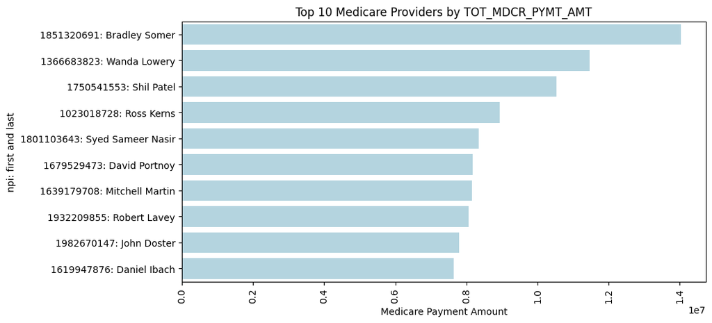

```python
# Let's create a bar chart that is already summarized
plt.figure(figsize=(10,5))
sns.barplot(data=res01_top10,
              x='sum_total_payment',
              y='provider_name',
            color='lightblue',
            errorbar=None
            )
plt.title('Top 10 Medicare Providers by TOT_MDCR_PYMT_AMT')
plt.xlabel('Medicare Payment Amount')
plt.xticks(rotation=90)
plt.ylabel('npi: first and last')
plt.show()
```

## RES02: TITLE “TOP 10 MEDICARE ORGANIZATIONS BY TOT_MDCR_PYMT_AMT”

```python
# We will use the org_summary dataframe to creat the table res02 and a chart displaying the top 10 organizations by tot_mdcr_pymnt_amt.
# This is going to be a similar process to res01.
res02 = org_summary_joined.groupby('org_name')['tot_mdcr_pymt_amt'].agg('sum').to_frame()
res02.head()
```

| org_name | tot_mdcr_pymt_amt |
| --- | --- |
| 1003002254: Walgreen Co. - TN | 18912.04 |
| 1003051129: Fcrx Sc Inc - SC | 2719.50 |
| 1003069832: Beulaville Pharmacy Inc - NC | 5269.42 |
| 1003096322: Publix Tennessee Llc - TN | 53208.70 |
| 1003110677: Charlotte Radiology Pa - NC | 41454.95 |

```python
# Let's clean this up by reseting our index and rename our columns
res02 = res02.rename(columns={'tot_mdcr_pymt_amt': 'sum_total_payment'})
```

```python
# Let's reset the index to remove multi-level columns
res02.reset_index(inplace=True)
```

```python
# Great, so we created our data frame and have cleaned up our dataframe with some slight modifications
res02
```

|  | org_name | sum_total_payment |
| --- | --- | --- |
| 0 | 1003002254: Walgreen Co. - TN | 18912.04 |
| 1 | 1003051129: Fcrx Sc Inc - SC | 2719.50 |
| 2 | 1003069832: Beulaville Pharmacy Inc - NC | 5269.42 |
| 3 | 1003096322: Publix Tennessee Llc - TN | 53208.70 |
| 4 | 1003110677: Charlotte Radiology Pa - NC | 41454.95 |
| ... | ... | ... |
| 4274 | 1992904551: Walgreen Co. - TN | 33590.35 |
| 4275 | 1992944631: Apothecary Consultants Llc - TN | 21744.71 |
| 4276 | 1992954598: Publix Tennessee Llc - TN | 21497.25 |
| 4277 | 1992965263: South Carolina Cvs Pharmacy, L.L.C... | 22675.24 |
| 4278 | 1992989552: Harris Teeter, Llc - NC | 11813.11 |

4279 rows × 2 columns

```python
# Now let's create a chart/table for the top 10 providers by using nlargest(10)
# We will now have a data set that just includes the top 10, which makes our work easier
res02_top10 = res02.nlargest(10, ['sum_total_payment'])
pd.set_option('display.float_format', lambda x: '%.2f' % x)
res02_top10
```

|  | org_name | sum_total_payment |
| --- | --- | --- |
| 2301 | 1538144910: Laboratory Corporation Of America ... | 234670845.50 |
| 740 | 1174009245: Vikor Scientific, Llc - SC | 42198509.44 |
| 3011 | 1699782722: Aegis Sciences Corporation - TN | 33066425.94 |
| 594 | 1134538713: Mako Medical Laboratories, Llc - NC | 31287531.70 |
| 1022 | 1235186800: Pathgroup Labs, Llc - TN | 21797255.78 |
| 2366 | 1548370745: Memphis Pathology Laboratory - TN | 20159010.52 |
| 3257 | 1750368700: Laboratory Corporation Of America ... | 19643419.72 |
| 554 | 1124417357: Aegis Sciences Corporation - TN | 16931095.66 |
| 2087 | 1487212551: Quest Diagnostics Clinical Laborat... | 15866817.32 |
| 2169 | 1508215922: Foundation Medicine, Inc. - NC | 15640629.10 |

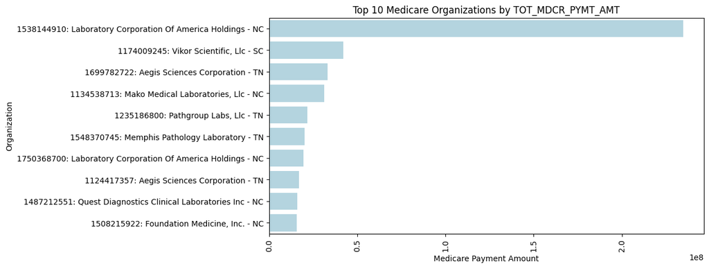

```python
#Let's create a bar chart that is already summarized
plt.figure(figsize=(10,5))
sns.barplot(data=res02_top10,
              x='sum_total_payment',
              y='org_name',
            color='lightblue',
            errorbar=None
            )
plt.title('Top 10 Medicare Organizations by TOT_MDCR_PYMT_AMT')
plt.xlabel('Medicare Payment Amount')
plt.xticks(rotation=90)
plt.ylabel('Organization')
plt.show()
```

## RES03: TITLE “NURSE PRACTITIONERS BY STATE”

```python
# We will use the physician_summary_joined dataframe to create a table and chart of "Nurse Practioners by State" using rndrng_prvdr_type and rndrng_prdvr_state_abrvtn
# We will perform very similar steps as we did in the previous charts and tables, but this time we will have to sharpen our filtering skills
# We will groupby two columns, reset the index and give a count by using size(), and size is a funtion that count items from a given array and give the output in the form of a number as size

res03 = physician_summary_joined.groupby(['rndrng_prvdr_state_abrvtn','rndrng_prvdr_type']).size().reset_index(name='count')
res03.head(5)
```

|  | rndrng_prvdr_state_abrvtn | rndrng_prvdr_type | count |
| --- | --- | --- | --- |
| 0 | NC | Addiction Medicine | 4 |
| 1 | NC | Advanced Heart Failure and Transplant Cardiology | 22 |
| 2 | NC | Allergy/ Immunology | 87 |
| 3 | NC | Anesthesiology | 733 |
| 4 | NC | Anesthesiology Assistant | 29 |

```python
# Let's start filtering for Nurse Practioner and get the counts for each state
# We can use a boolean mask
nurse = res03['rndrng_prvdr_type'] == 'Nurse Practitioner'
res03[nurse]
```

|  | rndrng_prvdr_state_abrvtn | rndrng_prvdr_type | count |
| --- | --- | --- | --- |
| 49 | NC | Nurse Practitioner | 4997 |
| 131 | SC | Nurse Practitioner | 2552 |
| 208 | TN | Nurse Practitioner | 5314 |

```python
# We can definitely drop the rndrng_prvdr_type column if needed, but we will keep it as it provides us evidence that we have filtered correctly and we have the right Provider Type
# So now let's sort our count values in descending order with sort_values() and then we will create a chart in the next code chunk
res03_ordered = res03[nurse].sort_values('count', ascending=False)
res03_ordered.head()
```

|  | rndrng_prvdr_state_abrvtn | rndrng_prvdr_type | count |
| --- | --- | --- | --- |
| 208 | TN | Nurse Practitioner | 5314 |
| 49 | NC | Nurse Practitioner | 4997 |
| 131 | SC | Nurse Practitioner | 2552 |

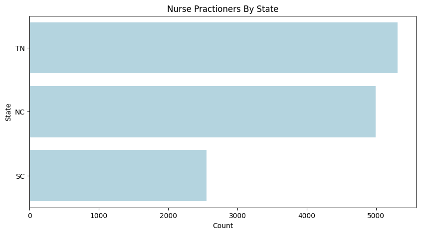

```python
#Let's create a bar chart that is already summarized
plt.figure(figsize=(10,5))
sns.barplot(data=res03_ordered,
              x='count',
              y='rndrng_prvdr_state_abrvtn',
            color='lightblue',
            errorbar=None
            )
plt.title('Nurse Practioners By State')
plt.xlabel('Count')
plt.xticks(rotation=0)
plt.ylabel('State')
plt.show()
```

## RES04: TITLE “ORGANIZATION TOTAL SPENDING BY STATE

```python
# # We will use the org_summary_joined dataframe to create a table and chart of "Organization Total Spending By Stae" using rndrng_prdvr_state_abrvtn and sum tot_mdcr_pymt_amt
# We will perform very similar steps as we did in the previous charts and tables
# We will be using grouby and aggregrate
res04 = org_summary_joined.groupby('rndrng_prvdr_state_abrvtn')['tot_mdcr_pymt_amt'].agg('sum').to_frame()
res04.head()
```

| rndrng_prvdr_state_abrvtn | tot_mdcr_pymt_amt |
| --- | --- |
| NC | 6.411749e+08 |
| SC | 2.890731e+08 |
| TN | 4.086610e+08 |

```python
# Let's rename tot_mdcr_pymt_amt
# Let's clean this up by reseting our index and rename our columns
res04 = res04.rename(columns={'tot_mdcr_pymt_amt': 'sum'})
```

```python
# Let's reset the column
res04.reset_index(inplace=True)
```

```python
# Let's order our sum
res04_ordered = res04.sort_values('sum', ascending=False)
pd.set_option('display.float_format', lambda x: '%.2f' % x)
res04_ordered.head()
```

|  | rndrng_prvdr_state_abrvtn | sum |
| --- | --- | --- |
| 0 | NC | 641174881.69 |
| 2 | TN | 408660971.70 |
| 1 | SC | 289073137.76 |

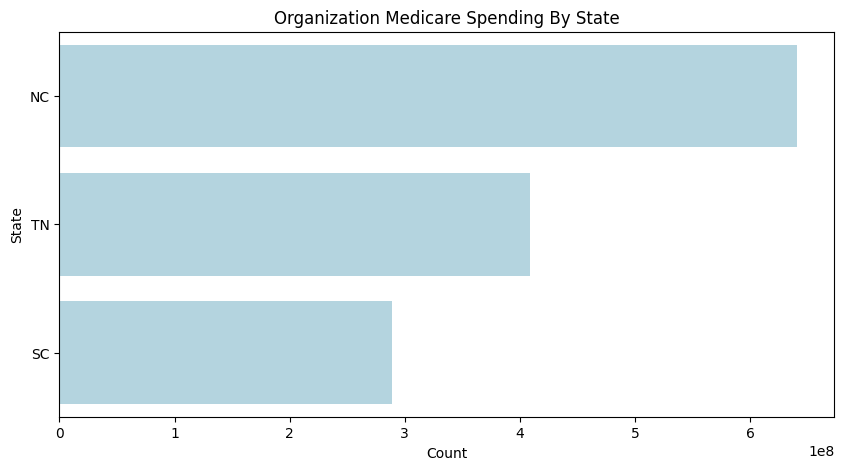

```python
# Let's create a bar chart that is already summarized
plt.figure(figsize=(10,5))
sns.barplot(data=res04_ordered,
              x='sum',
              y='rndrng_prvdr_state_abrvtn',
            color='lightblue',
            errorbar=None
            )
plt.title('Organization Medicare Spending By State')
plt.xlabel('Count')
plt.xticks(rotation=0)
plt.ylabel('State')
plt.show()
```

## RES05: TITLE “TOP 5 ORG SPENDING BY STATE AND SPECIALTY”

```python
# We will use the org_summary_joined dataframe to create a table and chart of "Top 5 Org Spending by State and Specialty"
# The objective is to sum 'tot_mdcr_pymt_amt' by rndrng_prvdr_type and rndrng_prdvr_state_abrvtn
# We will perform very similar steps as we did in the previous charts and tables, but this time we will have to sharpen our filtering skills
# We will use method chaining and the code/hint that was given from the instructions
res05 = (org_summary_joined
  .groupby(['rndrng_prvdr_state_abrvtn', 'rndrng_prvdr_type'])
  .agg({'tot_mdcr_pymt_amt': ['sum', 'count']})
)
# Present
res05.head()
```

| rndrng_prvdr_state_abrvtn | rndrng_prvdr_type | tot_mdcr_pymt_amt sum | tot_mdcr_pymt_amt count |
| --- | --- | --- | --- |
| NC | All Other Suppliers | 2.382725e+06 | 3 |
|  | Ambulance Service Provider | 1.445288e+08 | 198 |
|  | Ambulatory Surgical Center | 7.816452e+07 | 119 |
|  | Centralized Flu | 6.572196e+06 | 238 |
|  | Clinic or Group Practice | 1.826821e+04 | 2 |

```python
# We are going to deal with this multi-index problem by using the drop level function and reset_index
res05.columns = res05.columns.droplevel(0) # With drop_level(0) what we achieve is removing the empty first level from the column index.
res05 = res05.reset_index()
# Rename the columns
res05 = res05.rename(columns={'rndrng_prvdr_state_abrvtn': 'state' , 'rndrng_prvdr_type': 'provider_type', 'tot_mdcr_pymt_amt' : 'total_payment'})
#Select our columns, we are no longer using count
res05 = res05[['state', 'provider_type', 'sum']]
# present
res05.head()
```

|  | state | provider_type | sum |
| --- | --- | --- | --- |
| 0 | NC | All Other Suppliers | 2.382725e+06 |
| 1 | NC | Ambulance Service Provider | 1.445288e+08 |
| 2 | NC | Ambulatory Surgical Center | 7.816452e+07 |
| 3 | NC | Centralized Flu | 6.572196e+06 |
| 4 | NC | Clinic or Group Practice | 1.826821e+04 |

```python
# Double check our columns and our index
res05.columns
```

```
Index(['state', 'provider_type', 'sum'], dtype='object')
```

```python
# Let's do some sorting and present our table
res05 = (res05
    .sort_values(by=['state', 'sum'], ascending=False)     # Sorting a stat's sum number and going in descending order
    .groupby(['state'])                                    # To get each state, we are doing groupby
    .head(5)                                               # We are looking at the top 5 org spending by state and the provider type
)

# Change to notation
pd.set_option('display.float_format', lambda x: '%.2f' % x)

#Present
res05
```

|  | state | provider_type | sum |
| --- | --- | --- | --- |
| 30 | TN | Clinical Laboratory | 128751819.81 |
| 26 | TN | Ambulance Service Provider | 128737375.49 |
| 27 | TN | Ambulatory Surgical Center | 108401378.09 |
| 32 | TN | Mass Immunizer Roster Biller | 10849333.97 |
| 28 | TN | Centralized Flu | 7241423.04 |
| 14 | SC | Ambulance Service Provider | 109359849.01 |
| 15 | SC | Ambulatory Surgical Center | 78569205.43 |
| 18 | SC | Clinical Laboratory | 71811426.38 |
| 21 | SC | Mass Immunizer Roster Biller | 10384709.16 |
| 19 | SC | Independent Diagnostic Testing Facility (IDTF) | 9208319.55 |
| 5 | NC | Clinical Laboratory | 357244114.15 |
| 1 | NC | Ambulance Service Provider | 144528807.75 |
| 2 | NC | Ambulatory Surgical Center | 78164524.07 |
| 8 | NC | Mass Immunizer Roster Biller | 16004206.92 |
| 10 | NC | Pharmacy | 13438189.16 |

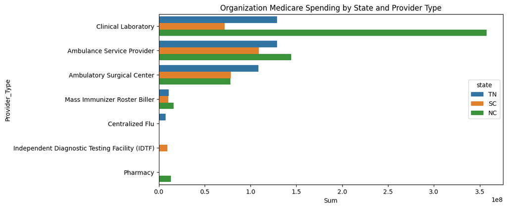

```python
# Let's create a bar chart that is already summarized
plt.figure(figsize=(10,5))
sns.barplot(data=res05,
              x='sum',
              y='provider_type',
            hue='state',
            errorbar=None
            )
plt.title('Organization Medicare Spending by State and Provider Type')
plt.xlabel('Sum')
plt.xticks(rotation=0)
plt.ylabel('Provider_Type')
plt.show()
```

## RES06: TITLE “TOP 5 PROVIDERs by SPENDING SPECIALTY”

```python
# We will use the physician_summary_joined dataframe to create a table and chart of "Top 5 Providers by Spending Speciality" where we sum tot_mdcr_pymt_amt and rndrng_prvdr_type
# We will perform very similar steps as we did in the previous charts and tables,
res06 = physician_summary_joined.groupby('rndrng_prvdr_type')['tot_mdcr_pymt_amt'].agg('sum').to_frame()
# Present
res06.head()
```

| rndrng_prvdr_type | tot_mdcr_pymt_amt |
| --- | --- |
| Addiction Medicine | 480013.86 |
| Advanced Heart Failure and Transplant Cardiology | 2739410.19 |
| Allergy/ Immunology | 24134842.54 |
| Anesthesiology | 75767720.25 |
| Anesthesiology Assistant | 829490.46 |

```python
# Let's clean this up by reseting our index and rename our columns
res06 = res06.rename(columns={'tot_mdcr_pymt_amt': 'sum_total_payment'})
```

```python
# Let's reset the index to remove multi-level columns
res06.reset_index(inplace=True)
```

```python
# We will now have a data set that just includes the top 5, which makes our work easier
res06_top5 = res06.nlargest(5, ['sum_total_payment'])
pd.set_option('display.float_format', lambda x: '%.2f' % x)
```

```python
# Present
res06_top5
```

|  | rndrng_prvdr_type | sum_total_payment |
| --- | --- | --- |
| 53 | Ophthalmology | 505082507.80 |
| 35 | Internal Medicine | 485139913.63 |
| 30 | Hematology-Oncology | 450390569.89 |
| 50 | Nurse Practitioner | 443327249.75 |
| 21 | Family Practice | 381226996.67 |

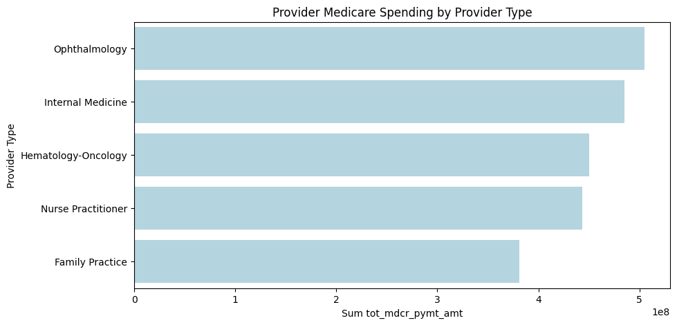

```python
# Let's create a bar chart that is already summarized
plt.figure(figsize=(10,5))
sns.barplot(data=res06_top5,
              x='sum_total_payment',
              y='rndrng_prvdr_type',
            color='lightblue',
            errorbar=None
            )
plt.title('Provider Medicare Spending by Provider Type')
plt.xlabel('Sum tot_mdcr_pymt_amt')
plt.xticks(rotation=0)
plt.ylabel('Provider Type')
plt.show()
```

## RES07: TITLE “TOP 10 GENERIC OPIATES BY TOTAL DAY SUPPLY”

```python
# Check column names
prescription.columns
```

```
Index(['...1', 'prscrbr_npi', 'brnd_name', 'gnrc_name', 'tot_clms',
       'tot_30day_fills', 'tot_day_suply', 'tot_drug_cst', 'tot_benes',
       'is_opiate'],
      dtype='object')
```

```python
# We will use the prescription dataframe to create a table and chart of "Top 10 Generic Opiates By Total Day Supply" with the following instructions
# Filter for is_opiate == 'Yes' , groupby gnrc_name and is_opiate, sum tot_day_supply
# This task will be similar to res03 with applying a boolean mask
res07 = prescription.groupby(['gnrc_name', 'is_opiate'])['tot_day_suply'].sum().reset_index(name='sum')
res07
```

|  | gnrc_name | is_opiate | sum |
| --- | --- | --- | --- |
| 0 | 0.9 % Sodium Chloride | No | 71382 |
| 1 | Abacavir Sulfate | No | 70885 |
| 2 | Abacavir Sulfate/Lamivudine | No | 47187 |
| 3 | Abacavir/Dolutegravir/Lamivudi | No | 522686 |
| 4 | Abacavir/Lamivudine/Zidovudine | No | 766 |
| ... | ... | ... | ... |
| 1356 | Zoledronic Acid | No | 3600 |
| 1357 | Zoledronic Acid/Mannitol-Water | No | 4695 |
| 1358 | Zolmitriptan | No | 33193 |
| 1359 | Zolpidem Tartrate | No | 23918454 |
| 1360 | Zonisamide | No | 1179336 |

1361 rows × 3 columns

```python
# Let's start filtering for Nurse Practioner and get the counts for each state
# We can use a boolean mask
opiate = res07['is_opiate'] == 'Yes'
res07[opiate]
```

|  | gnrc_name | is_opiate | sum |
| --- | --- | --- | --- |
| 16 | Acetaminophen With Codeine | Yes | 1208236 |
| 177 | Buprenorphine | Yes | 643438 |
| 178 | Buprenorphine Hcl | Yes | 1078222 |
| 185 | Butalbit/Acetamin/Caff/Codeine | Yes | 29142 |
| 188 | Butorphanol Tartrate | Yes | 69633 |
| 291 | Codeine Sulfate | Yes | 4116 |
| 292 | Codeine/Butalbital/Asa/Caffein | Yes | 11223 |
| 521 | Fentanyl | Yes | 2607143 |
| 522 | Fentanyl Citrate | Yes | 2908 |
| 622 | Hydrocodone Bitartrate | Yes | 222953 |
| 623 | Hydrocodone/Acetaminophen | Yes | 43131678 |
| 624 | Hydrocodone/Ibuprofen | Yes | 51614 |
| 633 | Hydromorphone Hcl | Yes | 1091654 |
| 752 | Levorphanol Tartrate | Yes | 62451 |
| 803 | Meperidine Hcl | Yes | 1110 |
| 813 | Methadone Hcl | Yes | 1330175 |
| 864 | Morphine Sulfate | Yes | 7015124 |
| 955 | Opium Tincture | Yes | 4799 |
| 956 | Opium/Belladonna Alkaloids | Yes | 72 |
| 971 | Oxycodone Hcl | Yes | 19525172 |
| 972 | Oxycodone Hcl/Acetaminophen | Yes | 25397036 |
| 975 | Oxymorphone Hcl | Yes | 482687 |
| 1012 | Pentazocine Hcl/Naloxone Hcl | Yes | 14171 |
| 1228 | Tapentadol Hcl | Yes | 530751 |
| 1289 | Tramadol Hcl | Yes | 24085196 |
| 1290 | Tramadol Hcl/Acetaminophen | Yes | 392020 |

```python
# We can definitely drop the is_opiate column if needed, but we will keep it as it provides us evidence that we have filtered correctly and we have the only opiates
# So now let's sort our count values in descending order with sort_values() and then we will create a chart in the next code chunk
res07_top10 = res07[opiate].nlargest(10,['sum'])
# Present
res07_top10
```

|  | gnrc_name | is_opiate | sum |
| --- | --- | --- | --- |
| 623 | Hydrocodone/Acetaminophen | Yes | 43131678 |
| 972 | Oxycodone Hcl/Acetaminophen | Yes | 25397036 |
| 1289 | Tramadol Hcl | Yes | 24085196 |
| 971 | Oxycodone Hcl | Yes | 19525172 |
| 864 | Morphine Sulfate | Yes | 7015124 |
| 521 | Fentanyl | Yes | 2607143 |
| 813 | Methadone Hcl | Yes | 1330175 |
| 16 | Acetaminophen With Codeine | Yes | 1208236 |
| 633 | Hydromorphone Hcl | Yes | 1091654 |
| 178 | Buprenorphine Hcl | Yes | 1078222 |

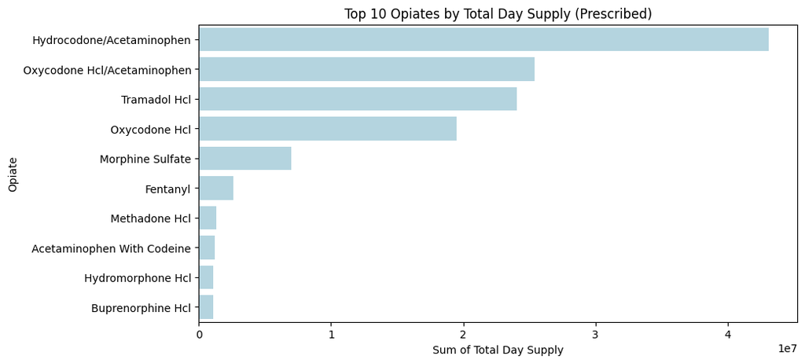

```python
# Let's create a bar chart that is already summarized
plt.figure(figsize=(10,5))
sns.barplot(data=res07_top10,
              x='sum',
              y='gnrc_name',
            color='lightblue',
            errorbar=None
            )
plt.title('Top 10 Opiates by Total Day Supply (Prescribed)')
plt.xlabel('Sum of Total Day Supply')
plt.xticks(rotation=0)
plt.ylabel('Opiate')
plt.show()
```

## RES08: TITLE “TOP 10 MOST EXPENSIVE DRUGS”

```python
# We will use the prescription dataframe to create a table and chart of "Top 10 Most Expensiv Drugs" with the following instructions
# Create a new column called claim_cost by (dividing tot_drug_cst by tot_clms) and then simply groupby brnd_name and take the mean of top 10 brnd_name
# We are going to create a new dataset by simply assinging prescription a new name and the reason is that we want to only manipulate the dataseet for this task
res08 = prescription
# Present
res08
```

|  | ...1 | prscrbr_npi | brnd_name | gnrc_name | tot_clms | tot_30day_fills | tot_day_suply | tot_drug_cst | tot_benes | is_opiate |
| --- | --- | --- | --- | --- | --- | --- | --- | --- | --- | --- |
| 0 | 0.0 | 1003000720 | Albuterol Sulfate Hfa | Albuterol Sulfate | 14 | 14.0 | 337 | 657.01 | 14.0 | No |
| 1 | 1.0 | 1003000720 | Amoxicillin-Clavulanate Potass | Amoxicillin/Potassium Clav | 34 | 34.0 | 328 | 412.06 | 34.0 | No |
| 2 | 2.0 | 1003000720 | Azithromycin | Azithromycin | 12 | 12.0 | 52 | 87.21 | 12.0 | No |
| 3 | 3.0 | 1003000720 | Cephalexin | Cephalexin | 25 | 25.0 | 211 | 144.27 | 25.0 | No |
| 4 | 4.0 | 1003000720 | Clindamycin Hcl | Clindamycin Hcl | 11 | 11.0 | 87 | 111.93 | 11.0 | No |
| ... | ... | ... | ... | ... | ... | ... | ... | ... | ... | ... |
| 197559 | 197981.0 | 1992993760 | Trazodone Hcl | Trazodone Hcl | 15 | 19.0 | 570 | 90.73 | NaN | No |
| 197560 | 197982.0 | 1992993760 | Valacyclovir | Valacyclovir Hcl | 24 | 34.0 | 1020 | 1811.73 | NaN | No |
| 197561 | 197983.0 | 1992993760 | Xarelto | Rivaroxaban | 19 | 19.0 | 570 | 8936.06 | NaN | No |
| 197562 | 197984.0 | 1992996292 | Hydrocodone-Acetaminophen | Hydrocodone/Acetaminophen | 36 | 36.0 | 83 | 127.46 | 35.0 | Yes |
| 197563 | 197985.0 | 1992996292 | Levothyroxine Sodium | Levothyroxine Sodium | 65 | 123.0 | 3660 | 1245.38 | 20.0 | No |

1975658 rows × 10 columns

```python
# Create a new variable called claim_cost
# This is going to include division of two columns
# tot_drug_cst / tot_clms
res08['claim_costs'] = res08['tot_drug_cst'] / res08['tot_clms']
res08
```

|  | ...1 | prscrbr_npi | brnd_name | gnrc_name | tot_clms | tot_30day_fills | tot_day_suply | tot_drug_cst | tot_benes | is_opiate | claim_costs |
| --- | --- | --- | --- | --- | --- | --- | --- | --- | --- | --- | --- |
| 0 | 0.0 | 1003000720 | Albuterol Sulfate Hfa | Albuterol Sulfate | 14 | 14.0 | 337 | 657.01 | 14.0 | No | 46.929286 |
| 1 | 1.0 | 1003000720 | Amoxicillin-Clavulanate Potass | Amoxicillin/Potassium Clav | 34 | 34.0 | 328 | 412.06 | 34.0 | No | 12.119412 |
| 2 | 2.0 | 1003000720 | Azithromycin | Azithromycin | 12 | 12.0 | 52 | 87.21 | 12.0 | No | 7.267500 |
| 3 | 3.0 | 1003000720 | Cephalexin | Cephalexin | 25 | 25.0 | 211 | 144.27 | 25.0 | No | 5.770800 |
| 4 | 4.0 | 1003000720 | Clindamycin Hcl | Clindamycin Hcl | 11 | 11.0 | 87 | 111.93 | 11.0 | No | 10.175455 |
| ... | ... | ... | ... | ... | ... | ... | ... | ... | ... | ... | ... |
| 197559 | 197981.0 | 1992993760 | Trazodone Hcl | Trazodone Hcl | 15 | 19.0 | 570 | 90.73 | NaN | No | 6.048667 |
| 197560 | 197982.0 | 1992993760 | Valacyclovir | Valacyclovir Hcl | 24 | 34.0 | 1020 | 1811.73 | NaN | No | 75.488750 |
| 197561 | 197983.0 | 1992993760 | Xarelto | Rivaroxaban | 19 | 19.0 | 570 | 8936.06 | NaN | No | 470.318947 |
| 197562 | 197984.0 | 1992996292 | Hydrocodone-Acetaminophen | Hydrocodone/Acetaminophen | 36 | 36.0 | 83 | 127.46 | 35.0 | Yes | 3.540556 |
| 197563 | 197985.0 | 1992996292 | Levothyroxine Sodium | Levothyroxine Sodium | 65 | 123.0 | 3660 | 1245.38 | 20.0 | No | 19.159692 |

1975658 rows × 11 columns

```python
# Let's group by and take the mean of
res08 = res08.groupby('brnd_name')['claim_costs'].mean().reset_index()
res08
```

|  | brnd_name | claim_costs |
| --- | --- | --- |
| 0 | Abacavir | 208.700912 |
| 1 | Abacavir-Lamivudine | 386.291946 |
| 2 | Abacavir-Lamivudine-Zidovudine | 1334.257857 |
| 3 | Abelcet | 398.400000 |
| 4 | Abilify | 1138.178852 |
| ... | ... | ... |
| 2231 | Zypitamag | 160.029063 |
| 2232 | Zyprexa | 1156.471484 |
| 2233 | Zyprexa Relprevv | 1175.260280 |
| 2234 | Zyprexa Zydis | 1458.265755 |
| 2235 | Zytiga | 10476.737746 |

2236 rows × 2 columns

```python
# Let's start selecting our data
# We want the top 10 brand names by claim costs
res08_top10 = res08.nlargest(10, ['claim_costs'])
res08_top10
```

|  | brnd_name | claim_costs |
| --- | --- | --- |
| 1302 | Myalept | 165046.884167 |
| 1841 | Strensiq | 112137.004791 |
| 224 | Berinert | 107622.892727 |
| 1690 | Ravicti | 95992.305556 |
| 766 | Firazyr | 75005.836171 |
| 1182 | Lumizyme | 73466.830372 |
| 361 | Chenodal | 65809.590000 |
| 61 | Aldurazyme | 63541.299286 |
| 184 | Ayvakit | 61090.000000 |
| 1634 | Procysbi | 57488.640638 |

```python
# We will rename our claim_costs column so that is more accurate and up to date with the code chunks
res08_top10 = res08_top10.rename(columns={'claim_costs': 'mean_claim_costs'})
res08_top10
```

|  | brnd_name | mean_claim_costs |
| --- | --- | --- |
| 1302 | Myalept | 165046.884167 |
| 1841 | Strensiq | 112137.004791 |
| 224 | Berinert | 107622.892727 |
| 1690 | Ravicti | 95992.305556 |
| 766 | Firazyr | 75005.836171 |
| 1182 | Lumizyme | 73466.830372 |
| 361 | Chenodal | 65809.590000 |
| 61 | Aldurazyme | 63541.299286 |
| 184 | Ayvakit | 61090.000000 |
| 1634 | Procysbi | 57488.640638 |

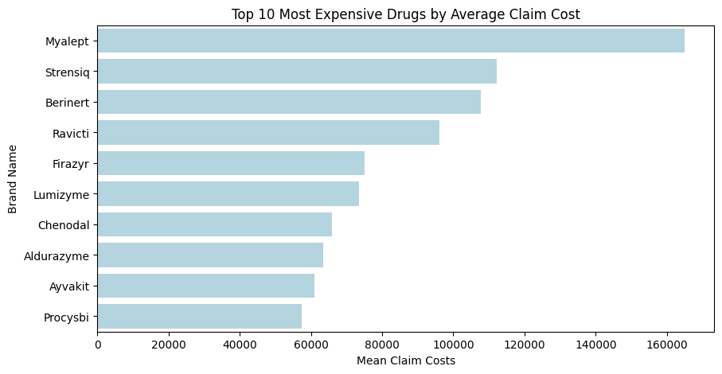

```python
# Let's create a bar chart that is already summarized
plt.figure(figsize=(10,5))
sns.barplot(data=res08_top10,
              x='mean_claim_costs',
              y='brnd_name',
            color='lightblue',
            errorbar=None
            )
plt.title('Top 10 Most Expensive Drugs by Average Claim Cost')
plt.xlabel('Mean Claim Costs')
plt.xticks(rotation=0)
plt.ylabel('Brand Name')
plt.show()
```

## RES09: TITLE “TOP 2 CITIES IN SC, NC, TN BY SUM OF TOTAL DAY SUPPLY FOR HYDROCODONE AND OXYCODONE”

```python
# We will use the prescription dataframe to create a table and chart of "Top 2 Cities in SC, NC, TN by Sum of Total Day Supply For Hydrocone and Oxycodone" with the following instructions
# We will create two graphs (1. Sum Total Day Supply and 2. Mean Day Supply)
# We are going to create a new dataset by simply assinging prescription a new name and the reason is that we want to only manipulate the dataseet for this task
res09 = prescription
# Present
res09
```

|  | ...1 | prscrbr_npi | brnd_name | gnrc_name | tot_clms | tot_30day_fills | tot_day_suply | tot_drug_cst | tot_benes | is_opiate | claim_costs |
| --- | --- | --- | --- | --- | --- | --- | --- | --- | --- | --- | --- |
| 0 | 0.0 | 1003000720 | Albuterol Sulfate Hfa | Albuterol Sulfate | 14 | 14.0 | 337 | 657.01 | 14.0 | No | 46.929286 |
| 1 | 1.0 | 1003000720 | Amoxicillin-Clavulanate Potass | Amoxicillin/Potassium Clav | 34 | 34.0 | 328 | 412.06 | 34.0 | No | 12.119412 |
| 2 | 2.0 | 1003000720 | Azithromycin | Azithromycin | 12 | 12.0 | 52 | 87.21 | 12.0 | No | 7.267500 |
| 3 | 3.0 | 1003000720 | Cephalexin | Cephalexin | 25 | 25.0 | 211 | 144.27 | 25.0 | No | 5.770800 |
| 4 | 4.0 | 1003000720 | Clindamycin Hcl | Clindamycin Hcl | 11 | 11.0 | 87 | 111.93 | 11.0 | No | 10.175455 |
| ... | ... | ... | ... | ... | ... | ... | ... | ... | ... | ... | ... |
| 197559 | 197981.0 | 1992993760 | Trazodone Hcl | Trazodone Hcl | 15 | 19.0 | 570 | 90.73 | NaN | No | 6.048667 |
| 197560 | 197982.0 | 1992993760 | Valacyclovir | Valacyclovir Hcl | 24 | 34.0 | 1020 | 1811.73 | NaN | No | 75.488750 |
| 197561 | 197983.0 | 1992993760 | Xarelto | Rivaroxaban | 19 | 19.0 | 570 | 8936.06 | NaN | No | 470.318947 |
| 197562 | 197984.0 | 1992996292 | Hydrocodone-Acetaminophen | Hydrocodone/Acetaminophen | 36 | 36.0 | 83 | 127.46 | 35.0 | Yes | 3.540556 |
| 197563 | 197985.0 | 1992996292 | Levothyroxine Sodium | Levothyroxine Sodium | 65 | 123.0 | 3660 | 1245.38 | 20.0 | No | 19.159692 |

1975658 rows × 11 columns

```python
# Let's begin with filtering gnrc_name for  'Hydrocodone/Acetaminophen' and 'Oxycodone'
# To do this we need to use the query_resultdf[df(...)] and we will need to use a 'or' statement
res09 = res09[(res09['gnrc_name'] == 'Hydrocodone/Acetaminophen') | (res09['gnrc_name'] == 'Oxycodone')]
res09
```

|  | ...1 | prscrbr_npi | brnd_name | gnrc_name | tot_clms | tot_30day_fills | tot_day_suply | tot_drug_cst | tot_benes | is_opiate | claim_costs |
| --- | --- | --- | --- | --- | --- | --- | --- | --- | --- | --- | --- |
| 79 | 79.0 | 1003007964 | Hydrocodone-Acetaminophen | Hydrocodone/Acetaminophen | 13 | 13.0 | 31 | 66.42 | 13.0 | Yes | 5.109231 |
| 165 | 165.0 | 1003010307 | Hydrocodone-Acetaminophen | Hydrocodone/Acetaminophen | 16 | 16.0 | 342 | 290.33 | 12.0 | Yes | 18.145625 |
| 415 | 415.0 | 1003013160 | Hydrocodone-Acetaminophen | Hydrocodone/Acetaminophen | 172 | 172.0 | 4716 | 4982.87 | 24.0 | Yes | 28.970174 |
| 496 | 496.0 | 1003013616 | Hydrocodone-Acetaminophen | Hydrocodone/Acetaminophen | 30 | 30.0 | 877 | 533.25 | NaN | Yes | 17.775000 |
| 724 | 725.0 | 1003027764 | Hydrocodone-Acetaminophen | Hydrocodone/Acetaminophen | 28 | 28.0 | 731 | 699.06 | 16.0 | Yes | 24.966429 |
| ... | ... | ... | ... | ... | ... | ... | ... | ... | ... | ... | ... |
| 197309 | 197731.0 | 1992979454 | Hydrocodone-Acetaminophen | Hydrocodone/Acetaminophen | 24 | 24.0 | 418 | 285.47 | NaN | Yes | 11.894583 |
| 197381 | 197803.0 | 1992979736 | Hydrocodone-Acetaminophen | Hydrocodone/Acetaminophen | 12 | 12.0 | 122 | 218.20 | NaN | Yes | 18.183333 |
| 197448 | 197870.0 | 1992985949 | Hydrocodone-Acetaminophen | Hydrocodone/Acetaminophen | 12 | 12.0 | 150 | 116.68 | NaN | Yes | 9.723333 |
| 197506 | 197928.0 | 1992987713 | Hydrocodone-Acetaminophen | Hydrocodone/Acetaminophen | 73 | 73.0 | 230 | 411.49 | 66.0 | Yes | 5.636849 |
| 197562 | 197984.0 | 1992996292 | Hydrocodone-Acetaminophen | Hydrocodone/Acetaminophen | 36 | 36.0 | 83 | 127.46 | 35.0 | Yes | 3.540556 |

21187 rows × 11 columns

```python
# Let's perform a concatenation as we already filtered our data and looking to just add two columns
# We will do this by using merge, specifically an inner join.
res09 = res09.merge(physician_summary_joined, how='inner')
res09
```

|  | ...1 | prscrbr_npi | brnd_name | gnrc_name | tot_clms | tot_30day_fills | tot_day_suply | tot_drug_cst | tot_benes | is_opiate | ... | primary_official_county_code | primary_official_county_name | county_weights | official_county_name | official_county_code | imprecise | military | timezone | geo_point | provider_name |
| --- | --- | --- | --- | --- | --- | --- | --- | --- | --- | --- | --- | --- | --- | --- | --- | --- | --- | --- | --- | --- | --- |
| 0 | 79.0 | 1003007964 | Hydrocodone-Acetaminophen | Hydrocodone/Acetaminophen | 13 | 13.0 | 31 | 66.42 | 13.0 | Yes | ... | 37067 | Forsyth | {"37067": "80.04", "37057": "19.96"} | Forsyth,Davidson | 37067,37057 | False | False | America/New_York | 36.0041, -80.37582 | 1245277532: Eric Hein |
| 1 | 79.0 | 1003007964 | Hydrocodone-Acetaminophen | Hydrocodone/Acetaminophen | 13 | 13.0 | 31 | 66.42 | 13.0 | Yes | ... | 45031 | Darlington | {"45031": "92.67", "45025": "6.92", "45061": "... | Darlington,Chesterfield,Lee | 45031,45025,45061 | False | False | America/New_York | 34.39887, -80.07734 | 1255447066: Stephen Skipper |
| 2 | 79.0 | 1003007964 | Hydrocodone-Acetaminophen | Hydrocodone/Acetaminophen | 13 | 13.0 | 31 | 66.42 | 13.0 | Yes | ... | 45031 | Darlington | {"45031": "92.67", "45025": "6.92", "45061": "... | Darlington,Chesterfield,Lee | 45031,45025,45061 | False | False | America/New_York | 34.39887, -80.07734 | 1316976186: Linda George |
| 3 | 79.0 | 1003007964 | Hydrocodone-Acetaminophen | Hydrocodone/Acetaminophen | 13 | 13.0 | 31 | 66.42 | 13.0 | Yes | ... | 45045 | Greenville | {"45045": "99.81", "45083": "0.19"} | Greenville,Spartanburg | 45045,45083 | False | False | America/New_York | 34.89755, -82.25845 | 1033179247: Joseph Pesce |
| 4 | 79.0 | 1003007964 | Hydrocodone-Acetaminophen | Hydrocodone/Acetaminophen | 13 | 13.0 | 31 | 66.42 | 13.0 | Yes | ... | 37119 | Mecklenburg | {"37119": "100"} | Mecklenburg | 37119 | False | False | America/New_York | 35.17854, -80.85386 | 1477852150: Maya Domoto |
| ... | ... | ... | ... | ... | ... | ... | ... | ... | ... | ... | ... | ... | ... | ... | ... | ... | ... | ... | ... | ... | ... |
| 6023493 | 186593.0 | 1992728141 | Hydrocodone-Acetaminophen | Hydrocodone/Acetaminophen | 2305 | 2305.0 | 64795 | 53085.77 | 669.0 | Yes | ... | 47065 | Hamilton | {"47065": "100"} | Hamilton | 47065 | False | False | America/New_York | 35.11406, -85.06431 | 1134286792: Brian Cooper |
| 6023494 | 186593.0 | 1992728141 | Hydrocodone-Acetaminophen | Hydrocodone/Acetaminophen | 2305 | 2305.0 | 64795 | 53085.77 | 669.0 | Yes | ... | 45019 | Charleston | {"45019": "100"} | Charleston | 45019 | False | False | America/New_York | 32.87848, -79.78989 | 1346240579: John Marino |
| 6023495 | 186593.0 | 1992728141 | Hydrocodone-Acetaminophen | Hydrocodone/Acetaminophen | 2305 | 2305.0 | 64795 | 53085.77 | 669.0 | Yes | ... | 37125 | Moore | {"37125": "100"} | Moore | 37125 | False | False | America/New_York | 35.19759, -79.46247 | 1962411058: Paul Kuzma |
| 6023496 | 186593.0 | 1992728141 | Hydrocodone-Acetaminophen | Hydrocodone/Acetaminophen | 2305 | 2305.0 | 64795 | 53085.77 | 669.0 | Yes | ... | 37001 | Alamance | {"37001": "68.81", "37135": "27.82", "37033": ... | Alamance,Orange,Caswell | 37001,37135,37033 | False | False | America/New_York | 36.14042, -79.26434 | 1619197845: Ana Benitez-Graham |
| 6023497 | 186593.0 | 1992728141 | Hydrocodone-Acetaminophen | Hydrocodone/Acetaminophen | 2305 | 2305.0 | 64795 | 53085.77 | 669.0 | Yes | ... | 47053 | Gibson | {"47053": "78.35", "47113": "15.39", "47033": ... | Gibson,Madison,Crockett | 47053,47113,47033 | False | False | America/Chicago | 35.82686, -88.92626 | 1932177615: Cynthia Swaim |

6023498 rows × 101 columns

```python
# Check out the columns that were merged and let's then filter for
res09.columns
```

```
Index(['...1', 'prscrbr_npi', 'brnd_name', 'gnrc_name', 'tot_clms',
       'tot_30day_fills', 'tot_day_suply', 'tot_drug_cst', 'tot_benes',
       'is_opiate',
       ...
       'primary_official_county_code', 'primary_official_county_name',
       'county_weights', 'official_county_name', 'official_county_code',
       'imprecise', 'military', 'timezone', 'geo_point', 'provider_name'],
      dtype='object', length=101)
```

```python
# Let's select the columns we want
res09 = res09[['official_usps_state_code', 'official_usps_city_name', 'tot_day_suply', 'tot_drug_cst']]
res09
```

|  | official_usps_state_code | official_usps_city_name | tot_day_suply | tot_drug_cst |
| --- | --- | --- | --- | --- |
| 0 | NC | Clemmons | 31 | 66.42 |
| 1 | SC | Hartsville | 31 | 66.42 |
| 2 | SC | Hartsville | 31 | 66.42 |
| 3 | SC | Greer | 31 | 66.42 |
| 4 | NC | Charlotte | 31 | 66.42 |
| ... | ... | ... | ... | ... |
| 6023493 | TN | Ooltewah | 64795 | 53085.77 |
| 6023494 | SC | Mount Pleasant | 64795 | 53085.77 |
| 6023495 | NC | Pinehurst | 64795 | 53085.77 |
| 6023496 | NC | Mebane | 64795 | 53085.77 |
| 6023497 | TN | Humboldt | 64795 | 53085.77 |

6023498 rows × 4 columns

```python
# Let's filter physician_summary fo official_usps_state_code for SC, NC, TN
# Using OR functions will be very useful here
res09 = res09[(res09['official_usps_state_code'] == 'SC') | (res09['official_usps_state_code'] == 'NC') | (res09['official_usps_state_code'] == 'TN')]
res09
```

|  | official_usps_state_code | official_usps_city_name | tot_day_suply | tot_drug_cst |
| --- | --- | --- | --- | --- |
| 0 | NC | Clemmons | 31 | 66.42 |
| 1 | SC | Hartsville | 31 | 66.42 |
| 2 | SC | Hartsville | 31 | 66.42 |
| 3 | SC | Greer | 31 | 66.42 |
| 4 | NC | Charlotte | 31 | 66.42 |
| ... | ... | ... | ... | ... |
| 6023493 | TN | Ooltewah | 64795 | 53085.77 |
| 6023494 | SC | Mount Pleasant | 64795 | 53085.77 |
| 6023495 | NC | Pinehurst | 64795 | 53085.77 |
| 6023496 | NC | Mebane | 64795 | 53085.77 |
| 6023497 | TN | Humboldt | 64795 | 53085.77 |

6021558 rows × 4 columns

```python
# Let's groupby ['offficial_usps_city_name, 'official_usps_state_code] and get the sum of and mean of tot_day_suply and tot_drug_cst
res09 = res09.groupby(['official_usps_state_code', 'official_usps_city_name']).agg({'tot_day_suply': ['sum', 'mean'], 'tot_drug_cst': ['sum','mean']}).reset_index()
res09
```

|  | official_usps_state_code | official_usps_city_name | tot_day_suply sum | tot_day_suply mean | tot_drug_cst sum | tot_drug_cst mean |
| --- | --- | --- | --- | --- | --- | --- |
| 0 | NC | Aberdeen | 2443882 | 1324.597290 | 2256777.74 | 1223.185767 |
| 1 | NC | Advance | 3679961 | 1435.802185 | 3386447.78 | 1321.282786 |
| 2 | NC | Ahoskie | 9579310 | 2114.171265 | 8971397.85 | 1980.003940 |
| 3 | NC | Albemarle | 15314180 | 1538.495077 | 14238915.53 | 1430.471723 |
| 4 | NC | Andrews | 675074 | 4927.547445 | 648225.25 | 4731.571168 |
| ... | ... | ... | ... | ... | ... | ... |
| 855 | TN | Whitwell | 414763 | 3427.793388 | 379801.40 | 3138.854545 |
| 856 | TN | Winchester | 9691195 | 2022.369574 | 9019713.86 | 1882.244128 |
| 857 | TN | Winfield | 191140 | 7645.600000 | 160745.53 | 6429.821200 |
| 858 | TN | Woodbury | 1656997 | 6182.824627 | 1489223.19 | 5556.802948 |
| 859 | TN | Yuma | 163872 | 20484.000000 | 131495.18 | 16436.897500 |

860 rows × 6 columns

```python
# Let's create columns and rename some columns
res09.rename(columns={'official_usps_state_code': 'state',
                              'official_usps_city_name': 'city',
                              'tot_day_suply': 'tot_day_supply',
                              'tot_drug_cst': 'tot_drug_cost'},inplace=True)
#Let's add a new column 'state_city'
res09['state_city'] = res09['state'] + ' - ' + res09['city']
#Present
res09
```

|  | state | city | tot_day_supply sum | tot_day_supply mean | tot_drug_cost sum | tot_drug_cost mean | state_city |
| --- | --- | --- | --- | --- | --- | --- | --- |
| 0 | NC | Aberdeen | 2443882 | 1324.597290 | 2256777.74 | 1223.185767 | NC - Aberdeen |
| 1 | NC | Advance | 3679961 | 1435.802185 | 3386447.78 | 1321.282786 | NC - Advance |
| 2 | NC | Ahoskie | 9579310 | 2114.171265 | 8971397.85 | 1980.003940 | NC - Ahoskie |
| 3 | NC | Albemarle | 15314180 | 1538.495077 | 14238915.53 | 1430.471723 | NC - Albemarle |
| 4 | NC | Andrews | 675074 | 4927.547445 | 648225.25 | 4731.571168 | NC - Andrews |
| ... | ... | ... | ... | ... | ... | ... | ... |
| 855 | TN | Whitwell | 414763 | 3427.793388 | 379801.40 | 3138.854545 | TN - Whitwell |
| 856 | TN | Winchester | 9691195 | 2022.369574 | 9019713.86 | 1882.244128 | TN - Winchester |
| 857 | TN | Winfield | 191140 | 7645.600000 | 160745.53 | 6429.821200 | TN - Winfield |
| 858 | TN | Woodbury | 1656997 | 6182.824627 | 1489223.19 | 5556.802948 | TN - Woodbury |
| 859 | TN | Yuma | 163872 | 20484.000000 | 131495.18 | 16436.897500 | TN - Yuma |

860 rows × 7 columns

```python
# We have a multi index and what we can do is try transfer the sum and mean into their own columns and then drop columns so that we can all the columns to be on the same level
res09.columns
```

```
MultiIndex([(         'state',     ''),
            (          'city',     ''),
            ('tot_day_supply',  'sum'),
            ('tot_day_supply', 'mean'),
            ( 'tot_drug_cost',  'sum'),
            ( 'tot_drug_cost', 'mean'),
            (    'state_city',     '')],
           )
```

```python
# Create new columns
res09['sum_day_supply'] = res09['tot_day_supply'][['sum']]
res09['mean_day_supply'] = res09['tot_day_supply'][['mean']]
res09['sum_drug_cost'] = res09['tot_drug_cost'][['sum']]
res09['mean_drug_cost'] = res09['tot_drug_cost'][['mean']]
#Present
res09
```

|  | state | city | tot_day_supply sum | tot_day_supply mean | tot_drug_cost sum | tot_drug_cost mean | state_city | sum_day_supply | mean_day_supply | sum_drug_cost | mean_drug_cost |
| --- | --- | --- | --- | --- | --- | --- | --- | --- | --- | --- | --- |
| 0 | NC | Aberdeen | 2443882 | 1324.597290 | 2256777.74 | 1223.185767 | NC - Aberdeen | 2443882 | 1324.597290 | 2256777.74 | 1223.185767 |
| 1 | NC | Advance | 3679961 | 1435.802185 | 3386447.78 | 1321.282786 | NC - Advance | 3679961 | 1435.802185 | 3386447.78 | 1321.282786 |
| 2 | NC | Ahoskie | 9579310 | 2114.171265 | 8971397.85 | 1980.003940 | NC - Ahoskie | 9579310 | 2114.171265 | 8971397.85 | 1980.003940 |
| 3 | NC | Albemarle | 15314180 | 1538.495077 | 14238915.53 | 1430.471723 | NC - Albemarle | 15314180 | 1538.495077 | 14238915.53 | 1430.471723 |
| 4 | NC | Andrews | 675074 | 4927.547445 | 648225.25 | 4731.571168 | NC - Andrews | 675074 | 4927.547445 | 648225.25 | 4731.571168 |
| ... | ... | ... | ... | ... | ... | ... | ... | ... | ... | ... | ... |
| 855 | TN | Whitwell | 414763 | 3427.793388 | 379801.40 | 3138.854545 | TN - Whitwell | 414763 | 3427.793388 | 379801.40 | 3138.854545 |
| 856 | TN | Winchester | 9691195 | 2022.369574 | 9019713.86 | 1882.244128 | TN - Winchester | 9691195 | 2022.369574 | 9019713.86 | 1882.244128 |
| 857 | TN | Winfield | 191140 | 7645.600000 | 160745.53 | 6429.821200 | TN - Winfield | 191140 | 7645.600000 | 160745.53 | 6429.821200 |
| 858 | TN | Woodbury | 1656997 | 6182.824627 | 1489223.19 | 5556.802948 | TN - Woodbury | 1656997 | 6182.824627 | 1489223.19 | 5556.802948 |
| 859 | TN | Yuma | 163872 | 20484.000000 | 131495.18 | 16436.897500 | TN - Yuma | 163872 | 20484.000000 | 131495.18 | 16436.897500 |

860 rows × 11 columns

```python
# Select columns
res09 = res09[['state',
                  'city',
                  'state_city',
                  'sum_day_supply',
                  'mean_day_supply',
                  'sum_drug_cost',
                  'mean_drug_cost']]
# Present
res09
```

|  | state | city | state_city | sum_day_supply | mean_day_supply | sum_drug_cost | mean_drug_cost |
| --- | --- | --- | --- | --- | --- | --- | --- |
| 0 | NC | Aberdeen | NC - Aberdeen | 2443882 | 1324.597290 | 2256777.74 | 1223.185767 |
| 1 | NC | Advance | NC - Advance | 3679961 | 1435.802185 | 3386447.78 | 1321.282786 |
| 2 | NC | Ahoskie | NC - Ahoskie | 9579310 | 2114.171265 | 8971397.85 | 1980.003940 |
| 3 | NC | Albemarle | NC - Albemarle | 15314180 | 1538.495077 | 14238915.53 | 1430.471723 |
| 4 | NC | Andrews | NC - Andrews | 675074 | 4927.547445 | 648225.25 | 4731.571168 |
| ... | ... | ... | ... | ... | ... | ... | ... |
| 855 | TN | Whitwell | TN - Whitwell | 414763 | 3427.793388 | 379801.40 | 3138.854545 |
| 856 | TN | Winchester | TN - Winchester | 9691195 | 2022.369574 | 9019713.86 | 1882.244128 |
| 857 | TN | Winfield | TN - Winfield | 191140 | 7645.600000 | 160745.53 | 6429.821200 |
| 858 | TN | Woodbury | TN - Woodbury | 1656997 | 6182.824627 | 1489223.19 | 5556.802948 |
| 859 | TN | Yuma | TN - Yuma | 163872 | 20484.000000 | 131495.18 | 16436.897500 |

860 rows × 7 columns

```python
# Now let's sort sum_day_supply from largest to smallest
res09.sort_values('sum_day_supply', ascending=False, inplace=True)

#Present
res09
```

|  | state | city | state_city | sum_day_supply | mean_day_supply | sum_drug_cost | mean_drug_cost |
| --- | --- | --- | --- | --- | --- | --- | --- |
| 55 | NC | Charlotte | NC - Charlotte | 674781531 | 1704.553341 | 6.291250e+08 | 1589.221100 |
| 277 | NC | Raleigh | NC - Raleigh | 476864396 | 1574.080027 | 4.447969e+08 | 1468.228556 |
| 761 | TN | Nashville | TN - Nashville | 407608608 | 1633.649454 | 3.800564e+08 | 1523.223226 |
| 747 | TN | Memphis | TN - Memphis | 352660574 | 1443.791755 | 3.297247e+08 | 1349.892438 |
| 713 | TN | Knoxville | TN - Knoxville | 342510679 | 1705.603063 | 3.192493e+08 | 1589.768411 |
| ... | ... | ... | ... | ... | ... | ... | ... |
| 250 | NC | Norwood | NC - Norwood | 12147 | 12147.000000 | 1.000583e+04 | 10005.830000 |
| 212 | NC | Marshville | NC - Marshville | 3065 | 3065.000000 | 3.367310e+03 | 3367.310000 |
| 441 | SC | Effingham | SC - Effingham | 3057 | 3057.000000 | 4.297460e+03 | 4297.460000 |
| 611 | TN | Caryville | TN - Caryville | 1277 | 1277.000000 | 1.755450e+03 | 1755.450000 |
| 548 | SC | Scranton | SC - Scranton | 796 | 796.000000 | 1.096640e+03 | 1096.640000 |

860 rows × 7 columns

```python
# Let's group by state and get the top 2 cities by using nlargest(2, 'sum_day_supply )
# In order to do this, we must understand that the groupby() function selects data and applys a function to the selected group of data
# So we will use the apply function and then apply()a .nlargest()
top2_cities_sum_supply = res09.groupby('state').apply(lambda x: x.nlargest(2,'sum_day_supply')).reset_index(drop=True)
#Present
top2_cities_sum_supply[['state','city', 'state_city', 'sum_day_supply']]
```

|  | state | city | state_city | sum_day_supply |
| --- | --- | --- | --- | --- |
| 0 | NC | Charlotte | NC - Charlotte | 674781531 |
| 1 | NC | Raleigh | NC - Raleigh | 476864396 |
| 2 | SC | Greenville | SC - Greenville | 303203144 |
| 3 | SC | Columbia | SC - Columbia | 227949372 |
| 4 | TN | Nashville | TN - Nashville | 407608608 |
| 5 | TN | Memphis | TN - Memphis | 352660574 |

```python
# Let's group by state and get the top 2 cities by using n_largest(2, mean_day_supply)
top2_cities_mean_supply = res09.groupby('state').apply(lambda x: x.nlargest(2,'mean_day_supply')).reset_index(drop=True)
#Present
top2_cities_mean_supply[['state', 'city', 'state_city', 'mean_day_supply']]
```

|  | state | city | state_city | mean_day_supply |
| --- | --- | --- | --- | --- |
| 0 | NC | Aulander | NC - Aulander | 80083.0 |
| 1 | NC | Winfall | NC - Winfall | 60038.0 |
| 2 | SC | Longs | SC - Longs | 55851.0 |
| 3 | SC | Denmark | SC - Denmark | 39250.0 |
| 4 | TN | Belvidere | TN - Belvidere | 43288.0 |
| 5 | TN | Puryear | TN - Puryear | 32783.0 |

```python
# Let's group by state and get the top 2 cities by using n_largest(2, 'sum_drug_cost)
top2_cities_sum_cost = res09.groupby('state').apply(lambda x: x.nlargest(2,'sum_drug_cost')).reset_index(drop=True)

# Change Notation
pd.set_option('display.float_format', lambda x: '%.2f' % x)

#Present
top2_cities_sum_cost[['state', 'city', 'state_city', 'sum_drug_cost']]
```

|  | state | city | state_city | sum_drug_cost |
| --- | --- | --- | --- | --- |
| 0 | NC | Charlotte | NC - Charlotte | 629124956.90 |
| 1 | NC | Raleigh | NC - Raleigh | 444796904.61 |
| 2 | SC | Greenville | SC - Greenville | 282061418.66 |
| 3 | SC | Columbia | SC - Columbia | 212635464.45 |
| 4 | TN | Nashville | TN - Nashville | 380056380.75 |
| 5 | TN | Memphis | TN - Memphis | 329724726.98 |

```python
# Let's group by state and get the top 2 cities by using n_largest(2, 'mean_drug_cost)
top2_cities_mean_cost = res09.groupby('state').apply(lambda x: x.nlargest(2,'mean_drug_cost')).reset_index(drop=True)
#Present
top2_cities_mean_cost[['state', 'city', 'state_city', 'mean_drug_cost']]
```

|  | state | city | state_city | mean_drug_cost |
| --- | --- | --- | --- | --- |
| 0 | NC | Aulander | NC - Aulander | 62959.940 |
| 1 | NC | Winfall | NC - Winfall | 46085.800 |
| 2 | SC | Longs | SC - Longs | 47601.030 |
| 3 | SC | Denmark | SC - Denmark | 34022.540 |
| 4 | TN | Belvidere | TN - Belvidere | 35945.040 |
| 5 | TN | Lobelville | TN - Lobelville | 29267.025 |

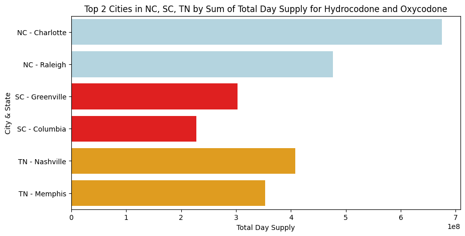

```python
# Let's create our graphs
# We will use a customized palette for the visuals and representation
my_palette = {'TN - Knoxville' : 'orange',
              'TN - Belvidere' : 'orange',
              'TN - Lobelville' : 'orange',
              'TN - Memphis' : 'orange',
              'TN - Puryear' : 'orange',
              'TN - Nashville' : 'orange',
              'SC - Greenville' : 'red',
              'SC - Columbia' : 'red',
              'SC - Longs' : 'red',
              'SC - Denmark' : 'red',
              'NC - Aulander' : 'lightblue',
              'NC - Winfall' : 'lightblue',
              'NC - Charlotte' : 'lightblue',
              'NC - Raleigh' : 'lightblue',
              }
# Let's plot top 2 cities with sum_day_supply
plt.figure(figsize=(10,5))
sns.barplot(data=top2_cities_sum_supply,
              x='sum_day_supply',
              y='state_city',
              palette=my_palette,
              errorbar=None
            );
plt.title('Top 2 Cities in NC, SC, TN by Sum of Total Day Supply for Hydrocodone and Oxycodone')
plt.xlabel('Total Day Supply')
plt.xticks(rotation=0)
plt.ylabel('City & State')
plt.show()
```

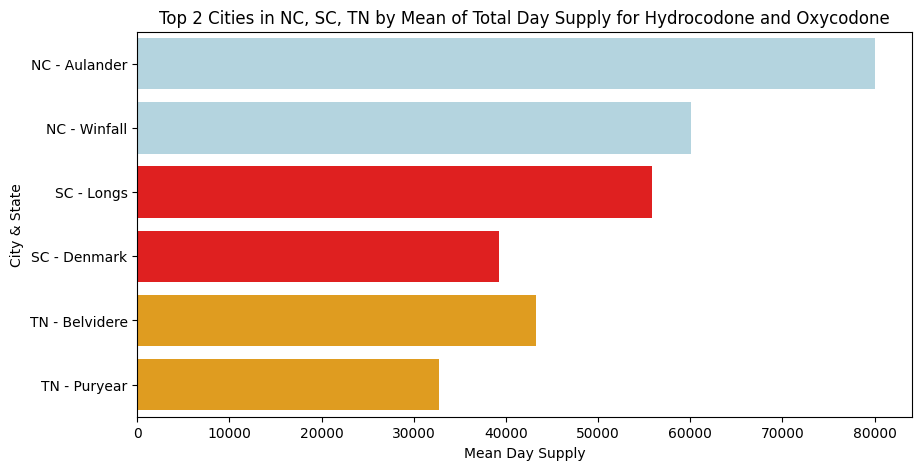

```python
# Let's create our graphs
# We will use a customized palette for the visuals and representation
my_palette = {'TN - Knoxville' : 'orange',
              'TN - Belvidere' : 'orange',
              'TN - Lobelville' : 'orange',
              'TN - Memphis' : 'orange',
              'TN - Puryear' : 'orange',
              'TN - Nashville' : 'orange',
              'SC - Greenville' : 'red',
              'SC - Columbia' : 'red',
              'SC - Longs' : 'red',
              'SC - Denmark' : 'red',
              'NC - Aulander' : 'lightblue',
              'NC - Winfall' : 'lightblue',
              'NC - Charlotte' : 'lightblue',
              'NC - Raleigh' : 'lightblue',
              }
# Let's plot top 2 cities with mean_day_supply
plt.figure(figsize=(10,5))
sns.barplot(data=top2_cities_mean_supply,
              x='mean_day_supply',
              y='state_city',
              palette=my_palette,
              errorbar=None
            );
plt.title('Top 2 Cities in NC, SC, TN by Mean of Total Day Supply for Hydrocodone and Oxycodone')
plt.xlabel('Mean Day Supply')
plt.xticks(rotation=0)
plt.ylabel('City & State')
plt.show()
```

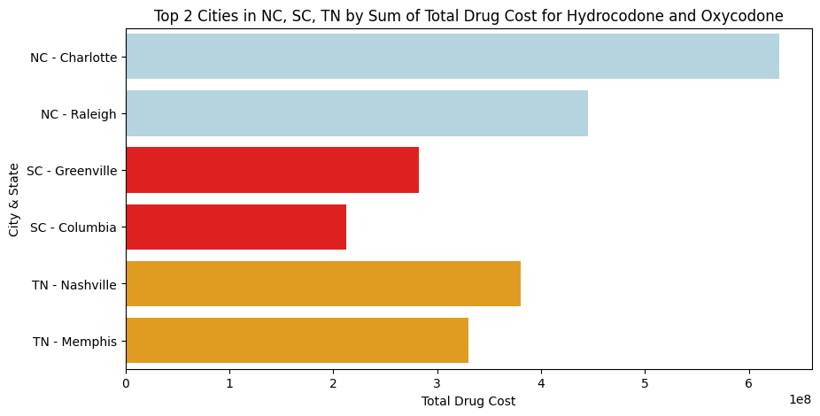

```python
# Let's create our graphs
# We will use a customized palette for the visuals and representation
my_palette = {'TN - Knoxville' : 'orange',
              'TN - Belvidere' : 'orange',
              'TN - Lobelville' : 'orange',
              'TN - Memphis' : 'orange',
              'TN - Puryear' : 'orange',
              'TN - Nashville' : 'orange',
              'SC - Greenville' : 'red',
              'SC - Columbia' : 'red',
              'SC - Longs' : 'red',
              'SC - Denmark' : 'red',
              'NC - Aulander' : 'lightblue',
              'NC - Winfall' : 'lightblue',
              'NC - Charlotte' : 'lightblue',
              'NC - Raleigh' : 'lightblue',
              }
# Let's plot top 2 cities with sum_drug_cost
plt.figure(figsize=(10,5))
sns.barplot(data=top2_cities_sum_cost,
              x='sum_drug_cost',
              y='state_city',
              palette=my_palette,
              errorbar=None
            );
plt.title('Top 2 Cities in NC, SC, TN by Sum of Total Drug Cost for Hydrocodone and Oxycodone')
plt.xlabel('Total Drug Cost')
plt.xticks(rotation=0)
plt.ylabel('City & State')
plt.show()
```

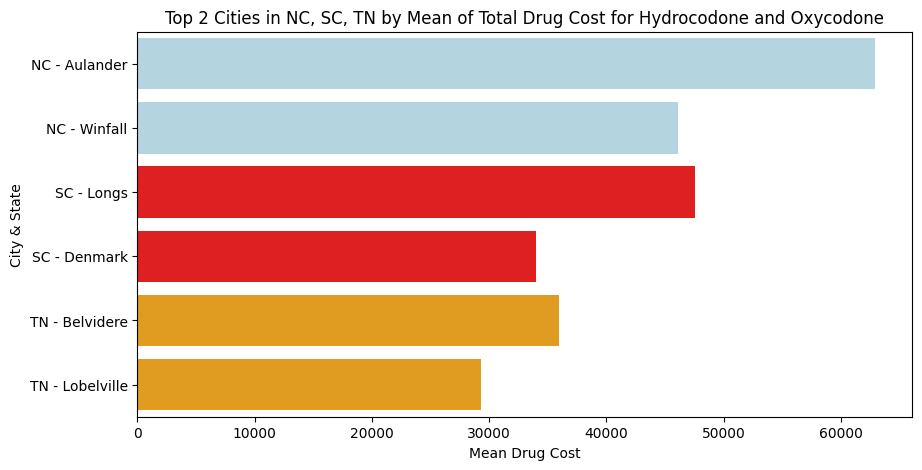

```python
# Let's create our graphs
# We will use a customized palette for the visuals and representation
my_palette = {'TN - Knoxville' : 'orange',
              'TN - Belvidere' : 'orange',
              'TN - Lobelville' : 'orange',
              'TN - Memphis' : 'orange',
              'TN - Puryear' : 'orange',
              'TN - Nashville' : 'orange',
              'SC - Greenville' : 'red',
              'SC - Columbia' : 'red',
              'SC - Longs' : 'red',
              'SC - Denmark' : 'red',
              'NC - Aulander' : 'lightblue',
              'NC - Winfall' : 'lightblue',
              'NC - Charlotte' : 'lightblue',
              'NC - Raleigh' : 'lightblue',
              }
# Let's plot top 2 cities with sum_day_supply
plt.figure(figsize=(10,5))
sns.barplot(data=top2_cities_mean_cost,
              x='mean_drug_cost',
              y='state_city',
              palette=my_palette,
              errorbar=None
            );
plt.title('Top 2 Cities in NC, SC, TN by Mean of Total Drug Cost for Hydrocodone and Oxycodone')
plt.xlabel('Mean Drug Cost')
plt.xticks(rotation=0)
plt.ylabel('City & State')
plt.show()
```

## What if anything does this tell you about hydrocodone and oxycodone prescriptions to Medicare Part D by city and state? What additional info would make for more interesting analysis?

### We find that Tennesee has different cities for majority of the graphs which shows that Tennessee is an active state in the opioid market , sum day supply is mostly in the millions or slightly less for majority of the state_cities, also North Carolina is the state that has the highest drug costs and has the highest day supply. Also majority of these states have different cities for each sum/mean day supply and sum/mean drug cost. Additional info that would make this more interesting is adding beneficiary info like those who have medicare and medicaid, the race of the beneificiares in these state-cities, the amount of nurse practioners in these states-cities, the amount of spending going into these state-cities, and more.

## RES10: TITLE "AN OPIATE A DAY"

```python
# Create a list for state codes we want
filtered_state_codes = ['SC', 'NC', 'TN']

#Create a list for the cities in res 09
filtered_city_names = ['Charlotte', 'Raleigh','Aulander', 'Winfall', 'Greenville', 'Columbia', 'Longs', 'Denmark','Nashville', 'Memphis', 'Belvidere', 'Puryear', 'Lobelville']

# Filter res10 by using isin() function
res10 = zips[zips['official_usps_state_code'].isin(filtered_state_codes)]

# Filter res10 again by using isin() function
res10 = res10[res10['official_usps_city_name'].isin(filtered_city_names)]

# Present
res10
```

|  | zip_code | official_usps_city_name | official_usps_state_code | official_state_name | zcta | zcta_parent | population | density | primary_official_county_code | primary_official_county_name | county_weights | official_county_name | official_county_code | imprecise | military | timezone | geo_point |
| --- | --- | --- | --- | --- | --- | --- | --- | --- | --- | --- | --- | --- | --- | --- | --- | --- | --- |
| 393 | 28278 | Charlotte | NC | North Carolina | True | NaN | 29347.0 | 397.7 | 37119 | Mecklenburg | {"37119": "100"} | Mecklenburg | 37119 | False | False | America/New_York | 35.12961, -81.00788 |
| 497 | 37215 | Nashville | TN | Tennessee | True | NaN | 22379.0 | 553.3 | 47037 | Davidson | {"47037": "99.71", "47187": "0.29"} | Davidson,Williamson | 47037,47187 | False | False | America/Chicago | 36.08192, -86.83469 |
| 508 | 38126 | Memphis | TN | Tennessee | True | NaN | 6329.0 | 1345.0 | 47157 | Shelby | {"47157": "100"} | Shelby | 47157 | False | False | America/Chicago | 35.12695, -90.04363 |
| 509 | 38131 | Memphis | TN | Tennessee | True | NaN | 0.0 | 0.0 | 47157 | Shelby | {"47157": "0"} | Shelby | 47157 | False | False | America/Chicago | 35.06631, -89.99205 |
| 1222 | 37205 | Nashville | TN | Tennessee | True | NaN | 23790.0 | 632.7 | 47037 | Davidson | {"47037": "100"} | Davidson | 47037 | False | False | America/Chicago | 36.11121, -86.87256 |
| ... | ... | ... | ... | ... | ... | ... | ... | ... | ... | ... | ... | ... | ... | ... | ... | ... | ... |
| 32005 | 38104 | Memphis | TN | Tennessee | True | NaN | 23456.0 | 1776.3 | 47157 | Shelby | {"47157": "100"} | Shelby | 47157 | False | False | America/Chicago | 35.1326, -90.00372 |
| 32946 | 27612 | Raleigh | NC | North Carolina | True | NaN | 39989.0 | 822.7 | 37183 | Wake | {"37183": "100"} | Wake | 37183 | False | False | America/New_York | 35.85334, -78.71023 |
| 32947 | 27805 | Aulander | NC | North Carolina | True | NaN | 4243.0 | 14.8 | 37091 | Hertford | {"37091": "50.7", "37015": "49.3"} | Hertford,Bertie | 37091,37015 | False | False | America/New_York | 36.20783, -77.08434 |
| 32966 | 29207 | Columbia | SC | South Carolina | True | NaN | 12270.0 | 72.4 | 45079 | Richland | {"45079": "100"} | Richland | 45079 | False | False | America/New_York | 34.04138, -80.84042 |
| 32967 | 29210 | Columbia | SC | South Carolina | True | NaN | 39312.0 | 949.8 | 45079 | Richland | {"45079": "72.82", "45063": "27.18"} | Richland,Lexington | 45079,45063 | False | False | America/New_York | 34.04612, -81.10661 |

132 rows × 17 columns

```python
# Groupby official_usps_state_code and official_usps_city_name and then sum the population
res10 = res10.groupby(['official_usps_state_code', 'official_usps_city_name']).agg({'population': 'sum'}).reset_index()

# Let's also rename population to make sure we know what it represents
res10 = res10.rename(columns={'population': 'sum_population'})

# Present
res10
```

|  | official_usps_state_code | official_usps_city_name | sum_population |
| --- | --- | --- | --- |
| 0 | NC | Aulander | 4243.0 |
| 1 | NC | Belvidere | 1035.0 |
| 2 | NC | Charlotte | 923655.0 |
| 3 | NC | Columbia | 4003.0 |
| 4 | NC | Greenville | 116440.0 |
| 5 | NC | Nashville | 17258.0 |
| 6 | NC | Raleigh | 555041.0 |
| 7 | NC | Winfall | 390.0 |
| 8 | SC | Columbia | 343984.0 |
| 9 | SC | Denmark | 4828.0 |
| 10 | SC | Greenville | 221595.0 |
| 11 | SC | Longs | 16130.0 |
| 12 | TN | Belvidere | 2153.0 |
| 13 | TN | Charlotte | 6245.0 |
| 14 | TN | Columbia | 61787.0 |
| 15 | TN | Denmark | 1036.0 |
| 16 | TN | Lobelville | 2241.0 |
| 17 | TN | Memphis | 694407.0 |
| 18 | TN | Nashville | 459738.0 |
| 19 | TN | Puryear | 2828.0 |

```python
# Now if you notice, we have a lot of rows so we are going to drop the rows/cities as we have results like Nashville, NC,  and Denmark, TN.
# We will drop by rows by referencing index numbers
res10 = res10.drop([1, 3, 4, 5, 13, 14, 15])

# Present
res10
```

|  | official_usps_state_code | official_usps_city_name | sum_population |
| --- | --- | --- | --- |
| 0 | NC | Aulander | 4243.0 |
| 2 | NC | Charlotte | 923655.0 |
| 6 | NC | Raleigh | 555041.0 |
| 7 | NC | Winfall | 390.0 |
| 8 | SC | Columbia | 343984.0 |
| 9 | SC | Denmark | 4828.0 |
| 10 | SC | Greenville | 221595.0 |
| 11 | SC | Longs | 16130.0 |
| 12 | TN | Belvidere | 2153.0 |
| 16 | TN | Lobelville | 2241.0 |
| 17 | TN | Memphis | 694407.0 |
| 18 | TN | Nashville | 459738.0 |
| 19 | TN | Puryear | 2828.0 |

```python
# Join this table with res09 on state and city.
res10 = res10.merge(res09,
            left_on=['official_usps_state_code', 'official_usps_city_name'],
            right_on=['state', 'city'],
            how='inner')

# Then create a new column "Day Supply Per Person" by Dividing Sum of sum_day_supply by sum_population
res10['day_supply_per_person'] = res09['sum_day_supply'] / res10['sum_population']

# Present
res10
```

|  | official_usps_state_code | official_usps_city_name | sum_population | (state, ) | (city, ) | (state_city, ) | (sum_day_supply, ) | (mean_day_supply, ) | (sum_drug_cost, ) | (mean_drug_cost, ) | day_supply_per_person |
| --- | --- | --- | --- | --- | --- | --- | --- | --- | --- | --- | --- |
| 0 | NC | Aulander | 4243.0 | NC | Aulander | NC - Aulander | 80083 | 80083.000000 | 6.295994e+04 | 62959.940000 | 575.979731 |
| 1 | NC | Charlotte | 923655.0 | NC | Charlotte | NC - Charlotte | 674781531 | 1704.553341 | 6.291250e+08 | 1589.221100 | 3.984129 |
| 2 | NC | Raleigh | 555041.0 | NC | Raleigh | NC - Raleigh | 476864396 | 1574.080027 | 4.447969e+08 | 1468.228556 | 17.258743 |
| 3 | NC | Winfall | 390.0 | NC | Winfall | NC - Winfall | 60038 | 60038.000000 | 4.608580e+04 | 46085.800000 | 39267.128205 |
| 4 | SC | Columbia | 343984.0 | SC | Columbia | SC - Columbia | 227949372 | 1580.588914 | 2.126355e+08 | 1474.403087 | 1.962516 |
| 5 | SC | Denmark | 4828.0 | SC | Denmark | SC - Denmark | 39250 | 39250.000000 | 3.402254e+04 | 34022.540000 | 108.106669 |
| 6 | SC | Greenville | 221595.0 | SC | Greenville | SC - Greenville | 303203144 | 1729.318512 | 2.820614e+08 | 1608.736725 | 98.035781 |
| 7 | SC | Longs | 16130.0 | SC | Longs | SC - Longs | 111702 | 55851.000000 | 9.520206e+04 | 47601.030000 | 926.301054 |
| 8 | TN | Belvidere | 2153.0 | TN | Belvidere | TN - Belvidere | 43288 | 43288.000000 | 3.594504e+04 | 35945.040000 | 11108.849512 |
| 9 | TN | Lobelville | 2241.0 | TN | Lobelville | TN - Lobelville | 51169 | 25584.500000 | 5.853405e+04 | 29267.025000 | 98040.378402 |
| 10 | TN | Memphis | 694407.0 | TN | Memphis | TN - Memphis | 352660574 | 1443.791755 | 3.297247e+08 | 1349.892438 | 0.342108 |
| 11 | TN | Nashville | 459738.0 | TN | Nashville | TN - Nashville | 407608608 | 1633.649454 | 3.800564e+08 | 1523.223226 | 0.174193 |
| 12 | TN | Puryear | 2828.0 | TN | Puryear | TN - Puryear | 32783 | 32783.000000 | 2.820664e+04 | 28206.640000 | 41.868105 |

```python
# Let's clean up theh column names by removing unecessary parantheses and commas
res10 = res10.rename(columns={('state', '' ): 'state',
                              ('city', ''): 'city',
                              ('state_city', ''): 'state_city',
                              ('sum_day_supply', ''): 'sum_day_supply',
                              ('mean_day_supply', ''): 'mean_day_supply',
                              ('sum_drug_cost', ''): 'sum_drug_cost',
                              ('mean_drug_cost', ''): 'mean_drug_cost'
                              })
# Change notation
pd.set_option('display.float_format', lambda x: '%.2f' % x)

# Present
res10
```

[output not shown]

```python
# Now let's clean up this data by selecting what we want
res10 = res10[['state_city', 'city', 'state', 'sum_population', 'sum_day_supply', 'mean_day_supply', 'sum_drug_cost', 'mean_drug_cost', 'day_supply_per_person']]

# Present
res10
```

|  | state_city | city | state | sum_population | sum_day_supply | mean_day_supply | sum_drug_cost | mean_drug_cost | day_supply_per_person |
| --- | --- | --- | --- | --- | --- | --- | --- | --- | --- |
| 0 | NC - Aulander | Aulander | NC | 4243.00 | 80083 | 80083.00 | 62959.94 | 62959.94 | 575.98 |
| 1 | NC - Charlotte | Charlotte | NC | 923655.00 | 674781531 | 1704.55 | 629124956.90 | 1589.22 | 3.98 |
| 2 | NC - Raleigh | Raleigh | NC | 555041.00 | 476864396 | 1574.08 | 444796904.61 | 1468.23 | 17.26 |
| 3 | NC - Winfall | Winfall | NC | 390.00 | 60038 | 60038.00 | 46085.80 | 46085.80 | 39267.13 |
| 4 | SC - Columbia | Columbia | SC | 343984.00 | 227949372 | 1580.59 | 212635464.45 | 1474.40 | 1.96 |
| 5 | SC - Denmark | Denmark | SC | 4828.00 | 39250 | 39250.00 | 34022.54 | 34022.54 | 108.11 |
| 6 | SC - Greenville | Greenville | SC | 221595.00 | 303203144 | 1729.32 | 282061418.66 | 1608.74 | 98.04 |
| 7 | SC - Longs | Longs | SC | 16130.00 | 111702 | 55851.00 | 95202.06 | 47601.03 | 926.30 |
| 8 | TN - Belvidere | Belvidere | TN | 2153.00 | 43288 | 43288.00 | 35945.04 | 35945.04 | 11108.85 |
| 9 | TN - Lobelville | Lobelville | TN | 2241.00 | 51169 | 25584.50 | 58534.05 | 29267.02 | 98040.38 |
| 10 | TN - Memphis | Memphis | TN | 694407.00 | 352660574 | 1443.79 | 329724726.98 | 1349.89 | 0.34 |
| 11 | TN - Nashville | Nashville | TN | 459738.00 | 407608608 | 1633.65 | 380056380.75 | 1523.22 | 0.17 |
| 12 | TN - Puryear | Puryear | TN | 2828.00 | 32783 | 32783.00 | 28206.64 | 28206.64 | 41.87 |

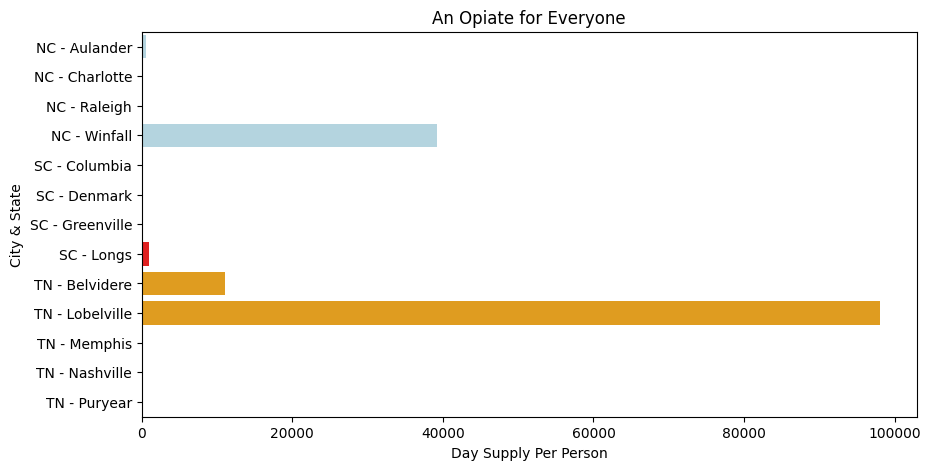

```python
# Let's create a graph
my_palette = {'TN - Knoxville' : 'orange',
              'TN - Belvidere' : 'orange',
              'TN - Lobelville' : 'orange',
              'TN - Memphis' : 'orange',
              'TN - Puryear' : 'orange',
              'TN - Nashville' : 'orange',
              'SC - Greenville' : 'red',
              'SC - Columbia' : 'red',
              'SC - Longs' : 'red',
              'SC - Denmark' : 'red',
              'NC - Aulander' : 'lightblue',
              'NC - Winfall' : 'lightblue',
              'NC - Charlotte' : 'lightblue',
              'NC - Raleigh' : 'lightblue',
              }
# Let's plot An Opiate for Everyone
plt.figure(figsize=(10,5))
sns.barplot(data=res10,
              x='day_supply_per_person',
              y='state_city',
              palette=my_palette,
              errorbar=None
            );
plt.title('An Opiate for Everyone')
plt.xlabel('Day Supply Per Person')
plt.xticks(rotation=0)
plt.ylabel('City & State')
plt.show()
# We see that there is a lot of variance so we will handle this by filtering
```

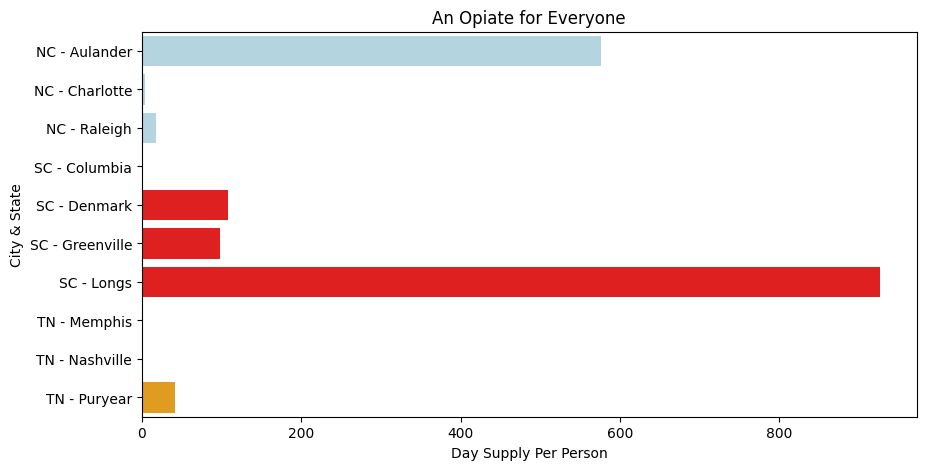

```python
# Let's filter Day_Supply_Per_Person < 100
res10_2 = res10[res10['day_supply_per_person'] < 1000]

# Let's plot
plt.figure(figsize=(10,5))
sns.barplot(data=res10_2,
              x='day_supply_per_person',
              y='state_city',
              palette=my_palette,
              errorbar=None
            );
plt.title('An Opiate for Everyone')
plt.xlabel('Day Supply Per Person')
plt.xticks(rotation=0)
plt.ylabel('City & State')
plt.show()
```

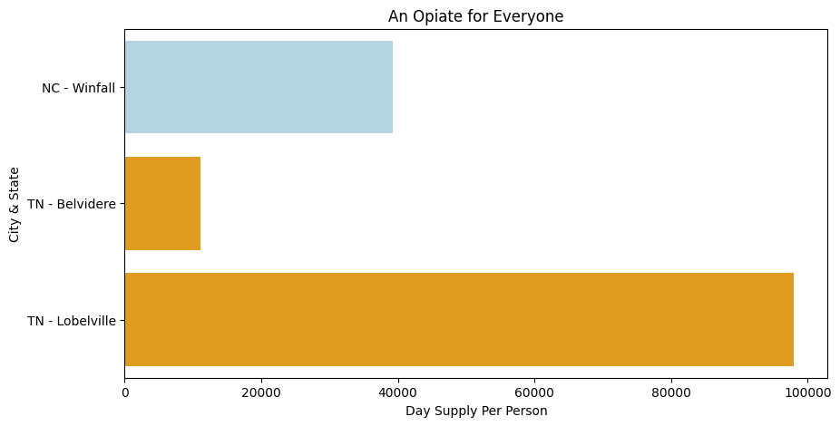

```python
# Let's filter Day_Supply_Per_Person < 100
res10_3 = res10[res10['day_supply_per_person'] > 1000]

# Let's plot
plt.figure(figsize=(10,5))
sns.barplot(data=res10_3,
              x='day_supply_per_person',
              y='state_city',
              palette=my_palette,
              errorbar=None
            );
plt.title('An Opiate for Everyone')
plt.xlabel('Day Supply Per Person')
plt.xticks(rotation=0)
plt.ylabel('City & State')
plt.show()
```